# What ?

In this notebook, we'll try to analyse data about the biggest prize in cinema, the Academy of Motion Picture Arts and Sciences Awards, also knows as the Oscars.

# Why

Mainly because I couldn't think of anything else. But also because making predictions using data is fun !

For those who're not on the know, and as it's the case for any sort of major competitions, major betting activity goes on about the results of these awards. From studios who want to know how much to spend on advertisement campaigns to push their candidates in the awards race, to cinephiles who want their favorites to win, to actors and directors whom careers can be shaped by the a nod in the right category, to gambling addicts who actually put money on several outcomes and expect returns on their investment, a lot is at stake.

What's interesting is the fact that, even though these awards should award excellence in artistic fields, some people turned predicting the results of these awards into a science of sorts (and go as far as calling themselves Oscarologists !). I will try to reproduce some of the general commmon "rules of thumb" in Oscarology into data-driven, statistical statements that befit the Scientific Methodology course.

# How ?

The idea is to use all sorts of movie metadata, as well as the history of several categories and the outcome of other awards that preceed the Oscars to make the right bet in the right category.

# 1. The Data

Gathering the right data for this task is both straightforward and tricky. The upside is that movie data is usually open and available in several forms (although rarely in immediately exploitable packages), so the first step is to define the questions we want to answer and then gather and format the data for further analysis.

I've started with the dataset from this Kaggle challenge which is provided by the Academy itself : https://www.kaggle.com/theacademy/academy-awards

It contains data on Oscar winners and nominees in all categories since 1927, which is the year the first Oscars were held. We'll use Pandas to manipulate the data and MatPlotLib to do most visualizations.

Here's an snippet of the dataset :

```python
import numpy as np
import pandas as pd
import matplotlib as plt
```

```python
df = pd.read_csv('database.csv')
```

```python
df[:20]
```

|  | Year | Ceremony | Award | Winner | Name | Film |
| --- | --- | --- | --- | --- | --- | --- |
| 0 | 1927/1928 | 1 | Actor | NaN | Richard Barthelmess | The Noose |
| 1 | 1927/1928 | 1 | Actor | 1.0 | Emil Jannings | The Last Command |
| 2 | 1927/1928 | 1 | Actress | NaN | Louise Dresser | A Ship Comes In |
| 3 | 1927/1928 | 1 | Actress | 1.0 | Janet Gaynor | 7th Heaven |
| 4 | 1927/1928 | 1 | Actress | NaN | Gloria Swanson | Sadie Thompson |
| 5 | 1927/1928 | 1 | Art Direction | NaN | Rochus Gliese | Sunrise |
| 6 | 1927/1928 | 1 | Art Direction | 1.0 | William Cameron Menzies | The Dove; Tempest |
| 7 | 1927/1928 | 1 | Art Direction | NaN | Harry Oliver | 7th Heaven |
| 8 | 1927/1928 | 1 | Cinematography | NaN | George Barnes | The Devil Dancer; The Magic Flame; Sadie Thompson |
| 9 | 1927/1928 | 1 | Cinematography | 1.0 | Charles Rosher | Sunrise |
| 10 | 1927/1928 | 1 | Cinematography | 1.0 | Karl Struss | Sunrise |
| 11 | 1927/1928 | 1 | Directing (Comedy Picture) | 1.0 | Lewis Milestone | Two Arabian Knights |
| 12 | 1927/1928 | 1 | Directing (Comedy Picture) | NaN | Ted Wilde | Speedy |
| 13 | 1927/1928 | 1 | Directing (Dramatic Picture) | 1.0 | Frank Borzage | 7th Heaven |
| 14 | 1927/1928 | 1 | Directing (Dramatic Picture) | NaN | Herbert Brenon | Sorrell and Son |
| 15 | 1927/1928 | 1 | Directing (Dramatic Picture) | NaN | King Vidor | The Crowd |
| 16 | 1927/1928 | 1 | Engineering Effects | NaN | Ralph Hammeras | NaN |
| 17 | 1927/1928 | 1 | Engineering Effects | 1.0 | Roy Pomeroy | Wings |
| 18 | 1927/1928 | 1 | Engineering Effects | NaN | Nugent Slaughter | NaN |
| 19 | 1927/1928 | 1 | Outstanding Picture | NaN | The Racket | The Caddo company |

The data provided here is quite rudimental : for each year, we get a list of entries, each corresponding to a nomination in a given category (the *Award* column), the name of the movie the nominee (the *Name* column), and the movie they're nominated for (the *Film* column). A win is designated by a "1.0" in the *Winner* column.

In order to get metadata for each film, we need to do some cleanup first ! Throughout their history, awards categories have been modified, added and dropped. Since our objective is to understand future trends, we're more interested in the "modern version" of each category.

Let's start by finding the list of all categories :

```python
categories = sorted(df['Award'].unique())
for i, c in enumerate(categories):
    print(str(i) + '. ' + c)
```

```
0. Actor
1. Actor in a Leading Role
2. Actor in a Supporting Role
3. Actress
4. Actress in a Leading Role
5. Actress in a Supporting Role
6. Animated Feature Film
7. Art Direction
8. Art Direction (Black and White)
9. Art Direction (Color)
10. Assistant Director
11. Award of Commendation
12. Best Motion Picture
13. Best Picture
14. Cinematography
15. Cinematography (Black and White)
16. Cinematography (Color)
17. Costume Design
18. Costume Design (Black and White)
19. Costume Design (Color)
20. Dance Direction
21. Directing
22. Directing (Comedy Picture)
23. Directing (Dramatic Picture)
24. Documentary
25. Documentary (Feature)
26. Documentary (Short Subject)
27. Engineering Effects
28. Film Editing
29. Foreign Language Film
30. Gordon E. Sawyer Award
31. Honorary Award
32. Honorary Foreign Language Film Award
33. Irving G. Thalberg Memorial Award
34. Jean Hersholt Humanitarian Award
35. John A. Bonner Medal of Commendation
36. Makeup
37. Makeup and Hairstyling
38. Medal of Commendation
39. Music (Adaptation Score)
```

[output cut: 59 more lines]

```
99. Writing (Original Story)
100. Writing (Screenplay Adapted from Other Material)
101. Writing (Screenplay Based on Material Previously Produced or Published)
102. Writing (Screenplay Based on Material from Another Medium)
103. Writing (Screenplay Written Directly for the Screen)
104. Writing (Screenplay Written Directly for the Screen, Based on Factual Material or on Story Material Not Previously Published or Produced)
105. Writing (Screenplay)
106. Writing (Screenplay, Adapted)
107. Writing (Screenplay, Based on Material from Another Medium)
108. Writing (Screenplay, Original)
109. Writing (Story and Screenplay)
110. Writing (Story and Screenplay, Based on Factual Material or Material Not Previously Published or Produced)
111. Writing (Story and Screenplay, Based on Material Not Previously Published or Produced)
112. Writing (Story and Screenplay, Written Directly for the Screen)
113. Writing (Title Writing)
```

Now here we'll have to do some manual intervention to make the data more uniform. We'll define, for each modern category, a list of older names for it and update the dataframe accordingly : (I have left out the technical awards (Special Effects, Sound Mixing) because they are not as "noteworthy" as the main awards, sorry behind-the-scenes guys and girls !)

```python
aliases = {"Actor in a Leading Role" : ["Actor"],
           "Actress in a Leading Role" : ["Actress"],
           "Directing" : ["Directing (Comedy Picture)","Directing (Dramatic Picture)"],
           "Best Picture" : ["Best Motion Picture", "Unique and Artistic Picture", "Outstanding Motion Picture",
                             "Outstanding Picture", "Outstanding Production"],
           "Foreign Language Film" : ["Special Foreign Language Film Award", "Honorary Foreign Language Film Award"],
           "Writing" : categories[94:]}

modern_names = dict()
for a in aliases :
    for category in aliases[a] : modern_names[category] = a
```

```python
modern_names
```

```
{'Actor': 'Actor in a Leading Role',
 'Actress': 'Actress in a Leading Role',
 'Best Motion Picture': 'Best Picture',
 'Directing (Comedy Picture)': 'Directing',
 'Directing (Dramatic Picture)': 'Directing',
 'Honorary Foreign Language Film Award': 'Foreign Language Film',
 'Outstanding Motion Picture': 'Best Picture',
 'Outstanding Picture': 'Best Picture',
 'Outstanding Production': 'Best Picture',
 'Special Foreign Language Film Award': 'Foreign Language Film',
 'Unique and Artistic Picture': 'Best Picture',
 'Writing (Adaptation)': 'Writing',
 'Writing (Adapted Screenplay)': 'Writing',
 'Writing (Motion Picture Story)': 'Writing',
 'Writing (Original Motion Picture Story)': 'Writing',
 'Writing (Original Screenplay)': 'Writing',
 'Writing (Original Story)': 'Writing',
 'Writing (Screenplay Adapted from Other Material)': 'Writing',
 'Writing (Screenplay Based on Material Previously Produced or Published)': 'Writing',
 'Writing (Screenplay Based on Material from Another Medium)': 'Writing',
 'Writing (Screenplay Written Directly for the Screen)': 'Writing',
 'Writing (Screenplay Written Directly for the Screen, Based on Factual Material or on Story Material Not Previously Published or Produced)': 'Writing',
 'Writing (Screenplay)': 'Writing',
 'Writing (Screenplay, Adapted)': 'Writing',
 'Writing (Screenplay, Based on Material from Another Medium)': 'Writing',
 'Writing (Screenplay, Original)': 'Writing',
 'Writing (Story and Screenplay)': 'Writing',
 'Writing (Story and Screenplay, Based on Factual Material or Material Not Previously Published or Produced)': 'Writing',
 'Writing (Story and Screenplay, Based on Material Not Previously Published or Produced)': 'Writing',
 'Writing (Story and Screenplay, Written Directly for the Screen)': 'Writing',
 'Writing (Title Writing)': 'Writing'}
```

*(All writing categories are mapped into one to account for the fact that for 50 years, writing both original and adapted screenplays was simply refered to as "Writing").*

Now let's rename our categories to match their modern names :

```python
df['Award_new'] = [modern_names[a] if a in modern_names else a for a in df['Award']]
```

```python
df[:20]
```

|  | Year | Ceremony | Award | Winner | Name | Film | Award_new |
| --- | --- | --- | --- | --- | --- | --- | --- |
| 0 | 1927/1928 | 1 | Actor | NaN | Richard Barthelmess | The Noose | Actor in a Leading Role |
| 1 | 1927/1928 | 1 | Actor | 1.0 | Emil Jannings | The Last Command | Actor in a Leading Role |
| 2 | 1927/1928 | 1 | Actress | NaN | Louise Dresser | A Ship Comes In | Actress in a Leading Role |
| 3 | 1927/1928 | 1 | Actress | 1.0 | Janet Gaynor | 7th Heaven | Actress in a Leading Role |
| 4 | 1927/1928 | 1 | Actress | NaN | Gloria Swanson | Sadie Thompson | Actress in a Leading Role |
| 5 | 1927/1928 | 1 | Art Direction | NaN | Rochus Gliese | Sunrise | Art Direction |
| 6 | 1927/1928 | 1 | Art Direction | 1.0 | William Cameron Menzies | The Dove; Tempest | Art Direction |
| 7 | 1927/1928 | 1 | Art Direction | NaN | Harry Oliver | 7th Heaven | Art Direction |
| 8 | 1927/1928 | 1 | Cinematography | NaN | George Barnes | The Devil Dancer; The Magic Flame; Sadie Thompson | Cinematography |
| 9 | 1927/1928 | 1 | Cinematography | 1.0 | Charles Rosher | Sunrise | Cinematography |
| 10 | 1927/1928 | 1 | Cinematography | 1.0 | Karl Struss | Sunrise | Cinematography |
| 11 | 1927/1928 | 1 | Directing (Comedy Picture) | 1.0 | Lewis Milestone | Two Arabian Knights | Directing |
| 12 | 1927/1928 | 1 | Directing (Comedy Picture) | NaN | Ted Wilde | Speedy | Directing |
| 13 | 1927/1928 | 1 | Directing (Dramatic Picture) | 1.0 | Frank Borzage | 7th Heaven | Directing |
| 14 | 1927/1928 | 1 | Directing (Dramatic Picture) | NaN | Herbert Brenon | Sorrell and Son | Directing |
| 15 | 1927/1928 | 1 | Directing (Dramatic Picture) | NaN | King Vidor | The Crowd | Directing |
| 16 | 1927/1928 | 1 | Engineering Effects | NaN | Ralph Hammeras | NaN | Engineering Effects |
| 17 | 1927/1928 | 1 | Engineering Effects | 1.0 | Roy Pomeroy | Wings | Engineering Effects |
| 18 | 1927/1928 | 1 | Engineering Effects | NaN | Nugent Slaughter | NaN | Engineering Effects |
| 19 | 1927/1928 | 1 | Outstanding Picture | NaN | The Racket | The Caddo company | Best Picture |

Sweet !

One more thing to regularize in the Year column, which before 1934 was expressed using two years (a season, e.g. 1927/1928)

```python
df['Year'].unique()
```

```
array(['1927/1928', '1928/1929', '1929/1930', '1930/1931', '1931/1932',
       '1932/1933', '1934', '1935', '1936', '1937', '1938', '1939', '1940',
       '1941', '1942', '1943', '1944', '1945', '1946', '1947', '1948',
       '1949', '1950', '1951', '1952', '1953', '1954', '1955', '1956',
       '1957', '1958', '1959', '1960', '1961', '1962', '1963', '1964',
       '1965', '1966', '1967', '1968', '1969', '1970', '1971', '1972',
       '1973', '1974', '1975', '1976', '1977', '1978', '1979', '1980',
       '1981', '1982', '1983', '1984', '1985', '1986', '1987', '1988',
       '1989', '1990', '1991', '1992', '1993', '1994', '1995', '1996',
       '1997', '1998', '1999', '2000', '2001', '2002', '2003', '2004',
       '2005', '2006', '2007', '2008', '2009', '2010', '2011', '2012',
       '2013', '2014', '2015'], dtype=object)
```

We'll simply drop off the first part of Year values that are longer than 4 characters :

```python
df['Year_new'] = [year[5:] if len(year) > 4 else year for year in df['Year']]
df[:5]
```

|  | Year | Ceremony | Award | Winner | Name | Film | Award_new | Year_new |
| --- | --- | --- | --- | --- | --- | --- | --- | --- |
| 0 | 1927/1928 | 1 | Actor | NaN | Richard Barthelmess | The Noose | Actor in a Leading Role | 1928 |
| 1 | 1927/1928 | 1 | Actor | 1.0 | Emil Jannings | The Last Command | Actor in a Leading Role | 1928 |
| 2 | 1927/1928 | 1 | Actress | NaN | Louise Dresser | A Ship Comes In | Actress in a Leading Role | 1928 |
| 3 | 1927/1928 | 1 | Actress | 1.0 | Janet Gaynor | 7th Heaven | Actress in a Leading Role | 1928 |
| 4 | 1927/1928 | 1 | Actress | NaN | Gloria Swanson | Sadie Thompson | Actress in a Leading Role | 1928 |

Now to the tricky part !

Since we need meta information about each movie, we'll need to "join" this dataframe with some richer dataset, and there are a lot of great options for that, depending on the kind of questions you'd want to have answers for. Here's a list : http://www.zanmel.com/2015/12/14/10-great-datasets-on-movies/

Some of these datasets contain extensive information about every aspect of the movie (cast and crew, user ratings, ..). For this project, however, this one would be a good starting point for a surface-level analysis of these movies : https://www.kaggle.com/orgesleka/imdbmovies/data

*Intermission : when I tried loading data directly from the CSV, I had an error coming from lines where the title of the movie itself contains commas (properly encoded as '\,'), which is apparently not too parser-friendly. I had to modify the original file and replace commas with tabs as separators .. it worked :)*

```python
imdb_df = pd.read_csv('imdb.csv', sep='\t') # lines containing movies with commas in their name
imdb_df[:5]
```

|  | fn | tid | title | wordsInTitle | url | imdbRating | ratingCount | duration | year | type | ... | News | RealityTV | Romance | SciFi | Short | Sport | TalkShow | Thriller | War | Western |
| --- | --- | --- | --- | --- | --- | --- | --- | --- | --- | --- | --- | --- | --- | --- | --- | --- | --- | --- | --- | --- | --- |
| 0 | titles01/tt0012349 | tt0012349 | Der Vagabund und das Kind (1921) | der vagabund und das kind | http://www.imdb.com/title/tt0012349/ | 8.4 | 40550.0 | 3240.0 | 1921.0 | video.movie | ... | 0 | 0 | 0 | 0 | 0 | 0 | 0 | 0 | 0 | 0 |
| 1 | titles01/tt0015864 | tt0015864 | Goldrausch (1925) | goldrausch | http://www.imdb.com/title/tt0015864/ | 8.3 | 45319.0 | 5700.0 | 1925.0 | video.movie | ... | 0 | 0 | 0 | 0 | 0 | 0 | 0 | 0 | 0 | 0 |
| 2 | titles01/tt0017136 | tt0017136 | Metropolis (1927) | metropolis | http://www.imdb.com/title/tt0017136/ | 8.4 | 81007.0 | 9180.0 | 1927.0 | video.movie | ... | 0 | 0 | 0 | 1 | 0 | 0 | 0 | 0 | 0 | 0 |
| 3 | titles01/tt0017925 | tt0017925 | Der General (1926) | der general | http://www.imdb.com/title/tt0017925/ | 8.3 | 37521.0 | 6420.0 | 1926.0 | video.movie | ... | 0 | 0 | 0 | 0 | 0 | 0 | 0 | 0 | 0 | 0 |
| 4 | titles01/tt0021749 | tt0021749 | Lichter der Großstadt (1931) | lichter der gro stadt | http://www.imdb.com/title/tt0021749/ | 8.7 | 70057.0 | 5220.0 | 1931.0 | video.movie | ... | 0 | 0 | 1 | 0 | 0 | 0 | 0 | 0 | 0 | 0 |

5 rows × 44 columns

```python
imdb_df.columns
```

```
Index(['fn', 'tid', 'title', 'wordsInTitle', 'url', 'imdbRating',
       'ratingCount', 'duration', 'year', 'type', 'nrOfWins',
       'nrOfNominations', 'nrOfPhotos', 'nrOfNewsArticles', 'nrOfUserReviews',
       'nrOfGenre', 'Action', 'Adult', 'Adventure', 'Animation', 'Biography',
       'Comedy', 'Crime', 'Documentary', 'Drama', 'Family', 'Fantasy',
       'FilmNoir', 'GameShow', 'History', 'Horror', 'Music', 'Musical',
       'Mystery', 'News', 'RealityTV', 'Romance', 'SciFi', 'Short', 'Sport',
       'TalkShow', 'Thriller', 'War', 'Western'],
      dtype='object')
```

# 2. The Questions

## 2.1. Movies

effect on box office themes

Let's take a look at our Best Picture category :

```python
df_picture = df[df['Award_new'] == 'Best Picture']
df_picture[['Year', 'Name', 'Award', 'Film', 'Winner']][:15]
```

|  | Year | Name | Award | Film | Winner |
| --- | --- | --- | --- | --- | --- |
| 19 | 1927/1928 | The Racket | Outstanding Picture | The Caddo company | NaN |
| 20 | 1927/1928 | 7th Heaven | Outstanding Picture | Fox | NaN |
| 21 | 1927/1928 | Wings | Outstanding Picture | Paramount Famous Lasky | 1.0 |
| 22 | 1927/1928 | Sunrise | Unique and Artistic Picture | Fox | 1.0 |
| 23 | 1927/1928 | The Crowd | Unique and Artistic Picture | Metro-Goldwyn-Mayer | NaN |
| 24 | 1927/1928 | Chang | Unique and Artistic Picture | Paramount Famous Lasky | NaN |
| 62 | 1928/1929 | Alibi | Outstanding Picture | Feature Productions | NaN |
| 63 | 1928/1929 | In Old Arizona | Outstanding Picture | Fox | NaN |
| 64 | 1928/1929 | The Broadway Melody | Outstanding Picture | Metro-Goldwyn-Mayer | 1.0 |
| 65 | 1928/1929 | Hollywood Revue | Outstanding Picture | Metro-Goldwyn-Mayer | NaN |
| 66 | 1928/1929 | The Patriot | Outstanding Picture | Paramount Famous Lasky | NaN |
| 100 | 1929/1930 | All Quiet on the Western Front | Outstanding Production | Universal | 1.0 |
| 101 | 1929/1930 | The Big House | Outstanding Production | Cosmopolitan | NaN |
| 102 | 1929/1930 | Disraeli | Outstanding Production | Warner Brothers | NaN |
| 103 | 1929/1930 | The Divorcee | Outstanding Production | Metro-Goldwyn-Mayer | NaN |

For some reason in this category, the production company takes over the *Film* column while the movie's name is in the *Name*, no big deal !

Now to get more information about each of these movies, we'll need a new source of data. There are many great options for that, depending on the kind of questions you'd want to have answers for. Here's a list : http://www.zanmel.com/2015/12/14/10-great-datasets-on-movies/

Since there is a lot (and I mean, *a lot*) of movie data in most movie datasets, and since we're only interested in a subset of characteristics over a very small subset of movies, a quick way to get the data is to use a free API like this one : http://www.omdbapi.com/

This will enable us to get a number of charactersitics for each movie we have in our dataset, so that we can create a new, richer dataframe we can start working on !

```python
"""
import urllib, json, string

OMDB_data = {}
for i, entry in df_picture.iterrows():
    key = (entry['Name'], entry['Year_new'])
    try:
        url = "http://www.omdbapi.com/?apikey=1bbe361c&t=%s&y=%s" % (key[0].replace(' ', '+'), key[1])
        response = urllib.request.urlopen(url)
        OMDB_data[key[0]] = json.loads(response.read())
    except:
        print('Error parsing : ' + key[0])

print('Done !')

# saving the data in a file because I can't rerun the info collection several times on a free account
with open('OMDB_data.txt', 'w') as f :
    f.write(json.dumps(OMDB_data))

"""
```

[output not shown]

The process -while successful !- isn't perfectly smooth, because for many movies the year of production and nomination don't match. Entries for several movies had to be manually updated (by querying http://www.omdbapi.com using the identifier from IMDB) These entries are :

[output not shown]

Now let's create a dataframe linking our original data with the OMDB data for each film :

```python
df_pic = df_picture.copy()
```

```python
import json

with open('OMDB_data.txt', 'r') as f :
    dt = json.loads(f.read())
```

```python
new_columns = ["Rated", "Released", "Runtime", "Genre", "Director", "Writer", "Actors", "Plot", "Language", "Country",
               "Awards", "Metascore", "imdbRating", "imdbVotes", "imdbID", "BoxOffice"]

for column in new_columns:
        df_picture[column] = df_picture['Name'].map(dict((m, dt[m][column] if column in dt[m] else 0) for m in dt))
```

[output not shown]

Let's do some formatting to have usable data later on.

PS : all the warning come from the fact that Pandas prefers using map() operations on columns rather than assignements to new values when processing some column. The output is still the same !

```python
df_picture['Runtime']    = [int(r[:-4]) for r in df_picture['Runtime']] # getting rid of " min" in the runtime column
df_picture['Year']       = df_picture['Year_new'].astype(int)

df_picture['imdbRating'][df_picture['imdbRating'] == 'N/A'] = 0 # The Patriot (1928) doesn't have an IMDB rating
df_picture['Metascore'][df_picture['Metascore'] == 'N/A'] = 0 # Many old movies don't have enough review online to get a Metascore
df_picture['imdbRating'] = df_picture['imdbRating'].astype(float)
df_picture['Metascore']  = df_picture['Metascore'].astype(int)

df_picture['BoxOffice'] = [-1 if x == 'N/A' else float(x[1:].replace(',', '')) for x in df_picture['BoxOffice']]

df_picture[:5]
```

[output not shown]

|  | Year | Ceremony | Award | Winner | Name | Film | Award_new | Year_new | Rated | Released | ... | Actors | Plot | Language | Country | Awards | Metascore | imdbRating | imdbVotes | imdbID | BoxOffice |
| --- | --- | --- | --- | --- | --- | --- | --- | --- | --- | --- | --- | --- | --- | --- | --- | --- | --- | --- | --- | --- | --- |
| 19 | 1928 | 1 | Outstanding Picture | NaN | The Racket | The Caddo company | Best Picture | 1928 | PASSED | 01 Nov 1928 | ... | Thomas Meighan, Louis Wolheim, Marie Prevost, ... | An honest police captain vows to bring down a ... | English | USA | N/A | 0 | 6.9 | 641 | tt0019304 | -1.0 |
| 20 | 1928 | 1 | Outstanding Picture | NaN | 7th Heaven | Fox | Best Picture | 1928 | NOT RATED | 30 Oct 1927 | ... | Janet Gaynor, Charles Farrell, Albert Gran, Da... | A street cleaner saves a young woman's life, a... | English | USA | Won 3 Oscars. Another 3 wins & 2 nominations. | 0 | 7.8 | 2,369 | tt0018379 | -1.0 |
| 21 | 1928 | 1 | Outstanding Picture | 1.0 | Wings | Paramount Famous Lasky | Best Picture | 1928 | PG-13 | 05 Jan 1929 | ... | Clara Bow, Charles 'Buddy' Rogers, Richard Arl... | Two young men, one rich, one middle class, who... | English | USA | Won 2 Oscars. Another 3 wins & 1 nomination. | 0 | 7.7 | 8,909 | tt0018578 | -1.0 |
| 22 | 1928 | 1 | Unique and Artistic Picture | 1.0 | Sunrise | Fox | Best Picture | 1928 | NOT RATED | 04 Nov 1927 | ... | George O'Brien, Janet Gaynor, Margaret Livings... | An allegorical tale about a man fighting the g... | English | USA | Won 3 Oscars. Another 2 wins & 2 nominations. | 0 | 8.2 | 34,510 | tt0018455 | -1.0 |
| 23 | 1928 | 1 | Unique and Artistic Picture | NaN | The Crowd | Metro-Goldwyn-Mayer | Best Picture | 1928 | NOT RATED | 03 Mar 1928 | ... | Eleanor Boardman, James Murray, Bert Roach, Es... | The life of a man and woman together in a larg... | N/A | USA | Nominated for 2 Oscars. Another 1 win. | 0 | 8.0 | 6,088 | tt0018806 | -1.0 |

5 rows × 24 columns

### Runtime statistics

Let's start by studying the typical runtime of an Oscar-nominated/winning movie since it's probably the easiest characteristic to observe.

```python
df_picture['Runtime'].describe()
```

```
count    531.000000
mean     124.798493
std       27.320026
min       66.000000
25%      105.500000
50%      120.000000
75%      138.000000
max      238.000000
Name: Runtime, dtype: float64
```

Nothing very impressive, the median oscar-nominated movie runs at 120 minutes, with a mean of 125 minutes and a standard deviation of about 27 minutes. The one thing that can be said here is that these movies are typically longer than "your average movie", which is generally run at the vicinity of 1 hour and a half. Let's get a look at the extremeties of these values :

```python
df_picture[['Name', 'Runtime', 'Year_new', 'Award']].sort_values(['Runtime'])
```

|  | Name | Runtime | Year_new | Award |
| --- | --- | --- | --- | --- |
| 244 | She Done Him Wrong | 66 | 1933 | Outstanding Production |
| 24 | Chang | 69 | 1928 | Unique and Artistic Picture |
| 1586 | The Ox-Bow Incident | 75 | 1943 | Outstanding Motion Picture |
| 305 | The White Parade | 80 | 1934 | Outstanding Production |
| 238 | A Farewell to Arms | 80 | 1933 | Outstanding Production |
| 179 | One Hour with You | 80 | 1932 | Outstanding Production |
| 180 | Shanghai Express | 82 | 1932 | Outstanding Production |
| 19 | The Racket | 84 | 1928 | Outstanding Picture |
| 302 | One Night of Love | 84 | 1934 | Outstanding Production |
| 7094 | Beauty and the Beast | 84 | 1991 | Best Picture |
| 489 | Three Smart Girls | 84 | 1936 | Outstanding Production |
| 606 | One Hundred Men and a Girl | 84 | 1937 | Outstanding Production |
| 103 | The Divorcee | 84 | 1930 | Outstanding Production |
| 143 | Skippy | 85 | 1931 | Outstanding Production |
| 2711 | High Noon | 85 | 1952 | Best Motion Picture |
| 2134 | Crossfire | 86 | 1947 | Best Motion Picture |
| 487 | The Story of Louis Pasteur | 86 | 1936 | Outstanding Production |
| 176 | The Champ | 86 | 1932 | Outstanding Production |
| 101 | The Big House | 87 | 1930 | Outstanding Production |
| 1397 | The Pied Piper | 87 | 1942 | Outstanding Motion Picture |
| 298 | Here Comes the Navy | 87 | 1934 | Outstanding Production |
| 299 | The House of Rothschild | 88 | 1934 | Outstanding Production |
| 1401 | Wake Island | 88 | 1942 | Outstanding Motion Picture |
| 1395 | The Magnificent Ambersons | 88 | 1942 | Outstanding Motion Picture |
| 876 | Love Affair | 88 | 1939 | Outstanding Production |
| 737 | Pygmalion | 89 | 1938 | Outstanding Production |
| 177 | Five Star Final | 89 | 1932 | Outstanding Production |
| 239 | 42nd Street | 89 | 1933 | Outstanding Production |
| 387 | Ruggles of Red Gap | 90 | 1935 | Outstanding Production |
| 734 | Four Daughters | 90 | 1938 | Outstanding Production |
| ... | ... | ... | ... | ... |
| 3925 | The Longest Day | 178 | 1962 | Best Picture |
| 3927 | Mutiny on the Bounty | 178 | 1962 | Best Picture |
| 8358 | The Lord of the Rings: The Two Towers | 179 | 2002 | Best Picture |
| 3561 | The Diary of Anne Frank | 180 | 1959 | Best Motion Picture |
| 9666 | The Wolf of Wall Street | 180 | 2013 | Best Picture |
| 4957 | Fiddler on the Roof | 181 | 1971 | Best Picture |
| 6983 | Dances With Wolves | 181 | 1990 | Best Picture |
| 4421 | The Sand Pebbles | 182 | 1966 | Best Picture |
| 5695 | The Deer Hunter | 183 | 1978 | Best Picture |
| 4960 | Nicholas and Alexandra | 183 | 1971 | Best Picture |
| 5372 | Barry Lyndon | 184 | 1975 | Best Picture |
| 5918 | Tess | 186 | 1980 | Best Picture |
| 3805 | Judgment at Nuremberg | 186 | 1961 | Best Motion Picture |
| 8011 | The Green Mile | 189 | 1999 | Best Picture |
| 7096 | JFK | 189 | 1991 | Best Picture |
| 6124 | Gandhi | 191 | 1982 | Best Picture |
| 4047 | Cleopatra | 192 | 1963 | Best Picture |
| 295 | Cleopatra | 192 | 1934 | Outstanding Production |
| 6235 | The Right Stuff | 193 | 1983 | Best Picture |
| 7787 | Titanic | 194 | 1997 | Best Picture |
| 7322 | Schindler's List | 195 | 1993 | Best Picture |
| 6019 | Reds | 195 | 1981 | Best Picture |
| 4294 | Doctor Zhivago | 197 | 1965 | Best Picture |
| 8468 | The Lord of the Rings: The Return of the King | 201 | 2003 | Best Picture |
| 3225 | Giant | 201 | 1956 | Best Motion Picture |
| 5267 | The Godfather Part II | 202 | 1974 | Best Picture |
| 3560 | Ben-Hur | 212 | 1959 | Best Motion Picture |
| 3924 | Lawrence of Arabia | 216 | 1962 | Best Picture |
| 3227 | The Ten Commandments | 220 | 1956 | Best Motion Picture |
| 874 | Gone with the Wind | 238 | 1939 | Outstanding Production |

531 rows × 4 columns

First step to get nominated to an oscar ? Make your movie as long as possible, with 120 minutes being the sweet spot !

How about actual winners ? *(I will constantly compare nominees and winners for the simple reason that the nominations are announced about a month before the actual awards ceremony, so you can maximize your bets by focusing on the disparities between the group of the nominees and the likely winner !)*

```python
df_picture_winners = df_picture[df_picture['Winner'] == 1]
df_picture_winners['Runtime'].describe()
```

```
count     90.000000
mean     138.255556
std       31.740366
min       90.000000
25%      116.500000
50%      128.500000
75%      160.750000
max      238.000000
Name: Runtime, dtype: float64
```

First thing that pops to the eye : the minimal runtime for an Oscar winner is 90 minutes ! Let's take a deeper look :

```python
df_picture_winners[['Year_new', 'Name', 'Runtime']].sort_values('Runtime')
```

|  | Year_new | Name | Runtime |
| --- | --- | --- | --- |
| 3094 | 1955 | Marty | 90 |
| 5583 | 1977 | Annie Hall | 93 |
| 22 | 1928 | Sunrise | 94 |
| 6875 | 1989 | Driving Miss Daisy | 99 |
| 64 | 1929 | The Broadway Melody | 100 |
| 9409 | 2011 | The Artist | 100 |
| 1912 | 1945 | The Lost Weekend | 101 |
| 1579 | 1943 | Casablanca | 102 |
| 4958 | 1971 | The French Connection | 104 |
| 5806 | 1979 | Kramer vs. Kramer | 105 |
| 301 | 1934 | It Happened One Night | 105 |
| 2968 | 1954 | On the Waterfront | 108 |
| 4531 | 1967 | In the Heat of the Night | 109 |
| 2353 | 1949 | All the King's Men | 110 |
| 237 | 1933 | Cavalcade | 112 |
| 178 | 1932 | Grand Hotel | 112 |
| 8698 | 2005 | Crash | 112 |
| 4747 | 1969 | Midnight Cowboy | 113 |
| 8355 | 2002 | Chicago | 113 |
| 2590 | 1951 | An American in Paris | 114 |
| 3445 | 1958 | Gigi | 115 |
| 4852 | 1970 | MA*S*H | 116 |
| 604 | 1937 | The Life of Emile Zola | 116 |
| 9288 | 2010 | The King's Speech | 118 |
| 2135 | 1947 | Gentleman's Agreement | 118 |
| 2840 | 1953 | From Here to Eternity | 118 |
| 1203 | 1941 | How Green Was My Valley | 118 |
| 7098 | 1991 | The Silence of the Lambs | 118 |
| 9787 | 2014 | Birdman or (The Unexpected Virtue of Ignorance) | 119 |
| 5482 | 1976 | Rocky | 120 |
| ... | ... | ... | ... |
| 8811 | 2006 | The Departed | 151 |
| 2710 | 1952 | The Greatest Show on Earth | 152 |
| 3806 | 1961 | West Side Story | 153 |
| 4638 | 1968 | Oliver! | 153 |
| 2244 | 1948 | Hamlet | 154 |
| 8127 | 2000 | Gladiator | 155 |
| 6341 | 1984 | Amadeus | 160 |
| 3326 | 1957 | The Bridge on the River Kwai | 161 |
| 6450 | 1985 | Out of Africa | 161 |
| 7665 | 1996 | The English Patient | 162 |
| 6667 | 1987 | The Last Emperor | 163 |
| 2028 | 1946 | The Best Years of Our Lives | 170 |
| 4174 | 1964 | My Fair Lady | 170 |
| 4853 | 1970 | Patton | 172 |
| 4296 | 1965 | The Sound of Music | 174 |
| 5062 | 1972 | The Godfather | 175 |
| 3223 | 1956 | Around the World in 80 Days | 175 |
| 482 | 1936 | The Great Ziegfeld | 176 |
| 7550 | 1995 | Braveheart | 178 |
| 385 | 1935 | Mutiny on the Bounty | 178 |
| 6983 | 1990 | Dances With Wolves | 181 |
| 5695 | 1978 | The Deer Hunter | 183 |
| 6124 | 1982 | Gandhi | 191 |
| 7787 | 1997 | Titanic | 194 |
| 7322 | 1993 | Schindler's List | 195 |
| 8468 | 2003 | The Lord of the Rings: The Return of the King | 201 |
| 5267 | 1974 | The Godfather Part II | 202 |
| 3560 | 1959 | Ben-Hur | 212 |
| 3924 | 1962 | Lawrence of Arabia | 216 |
| 874 | 1939 | Gone with the Wind | 238 |

90 rows × 3 columns

So except for 4 movies, every Oscar winner had gone beyond the 100 minutes mark, which cuts off ..

```python
len(df_picture[df_picture['Runtime'] < 100])
```

```
84
```

.. 84 movies from having any serious shot at winning !

*Second good advice: Make your movie longer than 100 minutes if you wanna win it*

#### Let's makes some plots

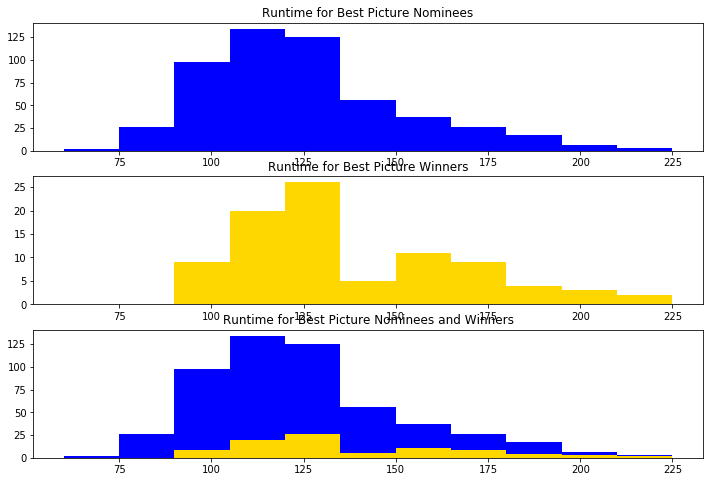

```python
import matplotlib.pyplot as plt
%matplotlib inline

from matplotlib.pylab import rcParams
rcParams['figure.figsize'] = 12, 8

# I've picked the bins to be increments of 15 minutes because kind of randomly, because it's easy to round it to something like
# this movie in 2 hours or 1h30 long

plt.subplot(311)
plt.hist(list(df_picture['Runtime']), bins=range(60,240,15), color='blue')
plt.title('Runtime for Best Picture Nominees')
plt.subplot(312)
plt.hist(list(df_picture_winners['Runtime']), bins=range(60,240,15), color='gold')
plt.title('Runtime for Best Picture Winners')
plt.subplot(313)
plt.hist(list(df_picture['Runtime']), bins=range(60,240,15), color='blue')
plt.hist(list(df_picture_winners['Runtime']), bins=range(60,240,15), color='gold')
plt.title('Runtime for Best Picture Nominees and Winners')
```

Interesting ! So as both histograms are mostly right-tailed, we can easily notice the absence of the "shorter" movies among the winners. There is also this strange double modality going on around the 150-180 minutes mark.

Moral of the story : Just make your movie as long as possible :D

One this we didn't accomodate for is the time evaluation. Is the runtime effect stationary ? Let's see :

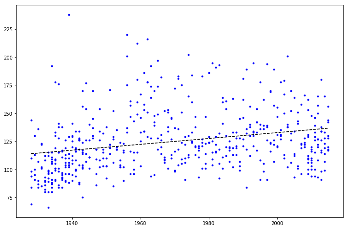

```python
x, y = df_picture['Year'], df_picture['Runtime']
m,b = np.polyfit(list(map(int, x)), y, 1)

plt.plot(x, y, 'b.', x, m*x+b, '--k')
```

How about winning though ?

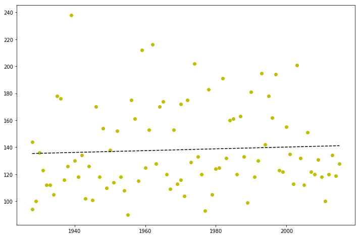

```python
x, y = df_picture_winners['Year'], df_picture_winners['Runtime']
m,b = np.polyfit(list(map(int, x)), y, 1)

plt.plot(x, y, 'yo', x, m*x+b, '--k')
```

Aha ! Practically no effect on the win, though (notice how the line's substially higher than the nomination one). This is, of course, the most basic analysis of the effect of time on this one characteristic. Further close inspection can reveal more, but let's say for now that the taste of the Academy has been quite stationary in its 90 years of award-giving ! (that is, longer movies are perceived as better !)

Let's now switch to a a new feature

### Ratings

Oscar-winning movies should be great, right ? Now to assess this greatness with an "objective" score, we can use IMDB's rating as a good indicator of a movie's appeal to audiences. This is usually contrasted with **movie critics** opinions (journalists who review movies for a job !) which tend to be more artsy and "serious" (a movie like *The Avengers* and *Transformers*, as much of crowd pleasers they can be, tend to disappoint critics), which can be represented by what's called a *metascore*, which is basically an aggregation of a wide group of reviewers (and unlike the *Tomato Score* from RottenTomatoes, it doesn't represent the percentage of reviewers who thought that a movie is "fresh" (not bad) but it's an actual grade on a scale from 0 to 100).

Let's start by getting a general view of audiences' reaction to Oscar nominated/winning movies : Two caveats : these ratings are recent and represent a movie's reception both before and after receiving the nomination/win, which means it can't be used as an indicator to make solid predictions (there is no data available showing movie scores before and after nominations/wins). The second caveat is that "Oscar type movies" are rarely watched by big audiences, and the people who go and watch them are more inclined to like them, which makes these ratings skewed in favor of these movies a little bit. In other words, the voting "pool" is not the same for popular and award-type movies.

Let's go !

```python
imdb_ratings = pd.Series(rating for rating in df_picture['imdbRating'] if rating > 0) # The Patriot (1928) doesn't have an IMDB rating

imdb_ratings.describe()
```

```
count    530.000000
mean       7.625472
std        0.539597
min        5.700000
25%        7.300000
50%        7.700000
75%        8.000000
max        9.300000
dtype: float64
```

That's quite interesting ! Mean and median are around 7.7 which is IMDB's score for potentially great movies (anything above 7.5 is a safe pick for a movie night !), but if that's the median, it means that 50% of Oscar-nominated movies are not *that* great, weird..

Histograms to the rescure !

```python
df_picture_winners[ ['Name', 'imdbRating']]
```

|  | Name | imdbRating |
| --- | --- | --- |
| 21 | Wings | 7.7 |
| 22 | Sunrise | 8.2 |
| 64 | The Broadway Melody | 6.2 |
| 100 | All Quiet on the Western Front | 8.1 |
| 140 | Cimarron | 6.0 |
| 178 | Grand Hotel | 7.6 |
| 237 | Cavalcade | 6.0 |
| 301 | It Happened One Night | 8.2 |
| 385 | Mutiny on the Bounty | 7.2 |
| 482 | The Great Ziegfeld | 6.8 |
| 604 | The Life of Emile Zola | 7.3 |
| 739 | You Can't Take It with You | 8.0 |
| 874 | Gone with the Wind | 8.2 |
| 1035 | Rebecca | 8.2 |
| 1203 | How Green Was My Valley | 7.8 |
| 1396 | Mrs. Miniver | 7.6 |
| 1579 | Casablanca | 8.5 |
| 1754 | Going My Way | 7.2 |
| 1912 | The Lost Weekend | 8.0 |
| 2028 | The Best Years of Our Lives | 8.1 |
| 2135 | Gentleman's Agreement | 7.4 |
| 2244 | Hamlet | 7.8 |
| 2353 | All the King's Men | 7.6 |
| 2470 | All about Eve | 8.3 |
| 2590 | An American in Paris | 7.2 |
| 2710 | The Greatest Show on Earth | 6.7 |
| 2840 | From Here to Eternity | 7.7 |
| 2968 | On the Waterfront | 8.2 |
| 3094 | Marty | 7.7 |
| 3223 | Around the World in 80 Days | 6.8 |
| ... | ... | ... |
| 6560 | Platoon | 8.1 |
| 6667 | The Last Emperor | 7.8 |
| 6769 | Rain Man | 8.0 |
| 6875 | Driving Miss Daisy | 7.4 |
| 6983 | Dances With Wolves | 8.0 |
| 7098 | The Silence of the Lambs | 8.6 |
| 7209 | Unforgiven | 8.2 |
| 7322 | Schindler's List | 8.9 |
| 7430 | Forrest Gump | 8.8 |
| 7550 | Braveheart | 8.4 |
| 7665 | The English Patient | 7.4 |
| 7787 | Titanic | 7.8 |
| 7901 | Shakespeare in Love | 7.2 |
| 8009 | American Beauty | 8.4 |
| 8127 | Gladiator | 8.5 |
| 8237 | A Beautiful Mind | 8.2 |
| 8355 | Chicago | 7.2 |
| 8468 | The Lord of the Rings: The Return of the King | 8.9 |
| 8585 | Million Dollar Baby | 8.1 |
| 8698 | Crash | 7.8 |
| 8811 | The Departed | 8.5 |
| 8931 | No Country for Old Men | 8.1 |
| 9047 | Slumdog Millionaire | 8.0 |
| 9166 | The Hurt Locker | 7.6 |
| 9288 | The King's Speech | 8.0 |
| 9409 | The Artist | 7.9 |
| 9532 | Argo | 7.7 |
| 9665 | 12 Years a Slave | 8.1 |
| 9787 | Birdman or (The Unexpected Virtue of Ignorance) | 7.8 |
| 9920 | Spotlight | 8.1 |

90 rows × 2 columns

```python
df_picture_winners['imdbRating'].describe()
```

```
count    90.000000
mean      7.842222
std       0.605402
min       6.000000
25%       7.600000
50%       8.000000
75%       8.200000
max       9.200000
Name: imdbRating, dtype: float64
```

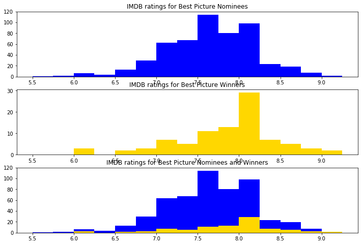

```python
plt.subplot(311)
plt.hist(imdb_ratings, bins=[5.5 + 0.25*t for t in range(16)], color='blue')
plt.title('IMDB ratings for Best Picture Nominees')
plt.subplot(312)
plt.hist(df_picture_winners['imdbRating'], bins=[5.5 + 0.25*t for t in range(16)], color='gold')
plt.title('IMDB ratings for Best Picture Winners')
plt.subplot(313)
plt.hist(imdb_ratings, bins=[5.5 + 0.25*t for t in range(16)], color='blue')
plt.hist(df_picture_winners['imdbRating'], bins=[5.5 + 0.25*t for t in range(16)], color='gold')
plt.title('IMDB ratings for Best Picture Nominees and Winners')
```

Now that's better, isn't it ? While the nomination historgram is kinda normally distributed (lots of values around the 7.5), the winners are much more likely to be in the upper 7s and cross to the 8s, which is quite an achievement in terms of IMDB ratings.

So if you're hesitating between two movies and one is in the 8s on IMDB and the other's not, this is a good indicator.

*Did you know ?* The academy is made up of about 6700 members who vote on the different categories. With such a big number of voters, one can see why their collective taste may actually align with IMDB votership.

Let's see the list of shame now : Bottom 20 oscar nominees of all timen as judged by the audience

```python
df_picture[['Name', 'Year_new', 'imdbRating']].sort_values(['imdbRating'])[1:20]
```

|  | Name | Year_new | imdbRating |
| --- | --- | --- | --- |
| 63 | In Old Arizona | 1929 | 5.7 |
| 296 | Flirtation Walk | 1934 | 5.8 |
| 302 | One Night of Love | 1934 | 5.9 |
| 237 | Cavalcade | 1933 | 6.0 |
| 62 | Alibi | 1929 | 6.0 |
| 140 | Cimarron | 1931 | 6.0 |
| 64 | The Broadway Melody | 1929 | 6.2 |
| 174 | Arrowsmith | 1932 | 6.2 |
| 4528 | Doctor Dolittle | 1967 | 6.2 |
| 2970 | Three Coins in the Fountain | 1954 | 6.3 |
| 143 | Skippy | 1931 | 6.3 |
| 298 | Here Comes the Navy | 1934 | 6.4 |
| 102 | Disraeli | 1930 | 6.4 |
| 304 | Viva Villa! | 1934 | 6.5 |
| 144 | Trader Horn | 1931 | 6.5 |
| 244 | She Done Him Wrong | 1933 | 6.5 |
| 5166 | A Touch of Class | 1973 | 6.5 |
| 480 | Anthony Adverse | 1936 | 6.5 |
| 4849 | Airport | 1970 | 6.6 |

As for the winners, the results aren't that catastrophic :

```python
df_picture_winners[['Name', 'Year_new', 'imdbRating']].sort_values(['imdbRating'])[:20]
```

|  | Name | Year_new | imdbRating |
| --- | --- | --- | --- |
| 140 | Cimarron | 1931 | 6.0 |
| 237 | Cavalcade | 1933 | 6.0 |
| 64 | The Broadway Melody | 1929 | 6.2 |
| 4050 | Tom Jones | 1963 | 6.7 |
| 2710 | The Greatest Show on Earth | 1952 | 6.7 |
| 3223 | Around the World in 80 Days | 1956 | 6.8 |
| 3445 | Gigi | 1958 | 6.8 |
| 482 | The Great Ziegfeld | 1936 | 6.8 |
| 7901 | Shakespeare in Love | 1998 | 7.2 |
| 6450 | Out of Africa | 1985 | 7.2 |
| 385 | Mutiny on the Bounty | 1935 | 7.2 |
| 8355 | Chicago | 2002 | 7.2 |
| 6016 | Chariots of Fire | 1981 | 7.2 |
| 2590 | An American in Paris | 1951 | 7.2 |
| 1754 | Going My Way | 1944 | 7.2 |
| 604 | The Life of Emile Zola | 1937 | 7.3 |
| 2135 | Gentleman's Agreement | 1947 | 7.4 |
| 6875 | Driving Miss Daisy | 1989 | 7.4 |
| 7665 | The English Patient | 1996 | 7.4 |
| 6237 | Terms of Endearment | 1983 | 7.4 |

What we learnt :

```
- An oscar win means probably that even the "average watcher" will like the movie (as suggested by the IMDB score)
- To make an oscar-winning movie, it doesn't hurt to make a crowd pleaser !
```

How about a little trip throught time ?

```
Slope : 0.0052685050088
```

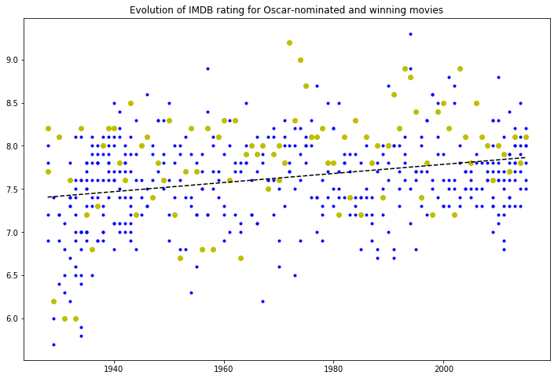

```python
x, y = df_picture[df_picture['imdbRating'] > 0]['Year'], df_picture[df_picture['imdbRating'] > 0]['imdbRating']
xw, yw = df_picture_winners['Year'], df_picture_winners['imdbRating']
m,b = np.polyfit(x, y, 1)

plt.title('Evolution of IMDB rating for Oscar-nominated and winning movies')
plt.plot(x, y, 'b.', xw, yw, 'yo', x, m*x+b, '--k')
print('Slope : ' + str(m))
```

Compared to the winners :

```
Slope : 0.00804378218024
```

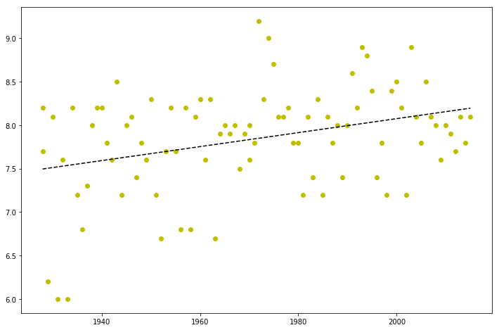

```python
m,b = np.polyfit(xw, yw, 1)

plt.plot(xw, yw, 'yo', xw, m*xw+b, '--k')
print('Slope : ' + str(m))
```

So now let's do the same thing, but from a critical reception perspective, represented by the Metascore :

```python
metascores = pd.Series(rating for rating in df_picture['Metascore'] if rating > 0) # The Patriot (1928) doesn't have an IMDB rating
metascores.describe()
```

```
count    243.000000
mean      80.946502
std       10.932986
min       42.000000
25%       75.000000
50%       83.000000
75%       89.000000
max      100.000000
dtype: float64
```

*There are noticeably less values for this column than the previous one because old (pre-internet) movies that aren't that well-known tend to be left out*

We notice that the scale for the metascore is a bit higher, where the mean is at 81 with 11 std. Let's see how it looks for winners :

```python
metascore_winners = pd.Series(int(score) for score in df_picture_winners['Metascore'] if score > 0)
metascore_winners.describe()
```

```
count     52.000000
mean      84.538462
std        8.991197
min       65.000000
25%       79.000000
50%       86.000000
75%       91.250000
max      100.000000
dtype: float64
```

No suprise here, winning movies tend to have better metascores! Let's see how the spread looks like :

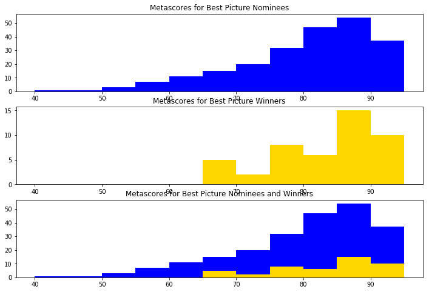

```python
plt.subplot(311)
plt.hist(metascores, bins=[40 + 5*t for t in range(12)], color='blue')
plt.title('Metascores for Best Picture Nominees')
plt.subplot(312)
plt.hist(metascore_winners, bins=[40 + 5*t for t in range(12)], color='gold')
plt.title('Metascores for Best Picture Winners')
plt.subplot(313)
plt.hist(metascores, bins=[40 + 5*t for t in range(12)], color='blue')
plt.hist(metascore_winners, bins=[40 + 5*t for t in range(12)], color='gold')
plt.title('Metascores for Best Picture Nominees and Winners')
```

```python
df_picture[df_picture['Metascore'] > 0][['Name', 'Year_new', 'Metascore']].sort_values(['Metascore'])[:20]
```

|  | Name | Year_new | Metascore |
| --- | --- | --- | --- |
| 4849 | Airport | 1970 | 42 |
| 9411 | Extremely Loud & Incredibly Close | 2011 | 46 |
| 6984 | Ghost | 1990 | 52 |
| 9163 | The Blind Side | 2009 | 53 |
| 6766 | The Accidental Tourist | 1988 | 53 |
| 6876 | Field of Dreams | 1989 | 57 |
| 5585 | Julia | 1977 | 58 |
| 9046 | The Reader | 2008 | 58 |
| 4745 | Butch Cassidy and the Sundance Kid | 1969 | 58 |
| 5697 | Midnight Express | 1978 | 59 |
| 7899 | Life Is Beautiful | 1998 | 59 |
| 7208 | Scent of a Woman | 1992 | 59 |
| 6985 | The Godfather, Part III | 1990 | 60 |
| 4047 | Cleopatra | 1963 | 60 |
| 295 | Cleopatra | 1934 | 60 |
| 8011 | The Green Mile | 1999 | 61 |
| 5807 | Norma Rae | 1979 | 61 |
| 9412 | The Help | 2011 | 62 |
| 6233 | The Big Chill | 1983 | 62 |
| 7206 | A Few Good Men | 1992 | 62 |

```python
df_picture_winners[df_picture_winners['Metascore'] > 0][['Name', 'Year_new', 'Metascore']].sort_values(['Metascore'])[:10]
```

|  | Name | Year_new | Metascore |
| --- | --- | --- | --- |
| 6769 | Rain Man | 1988 | 65 |
| 8127 | Gladiator | 2000 | 67 |
| 7550 | Braveheart | 1995 | 68 |
| 5482 | Rocky | 1976 | 69 |
| 8698 | Crash | 2005 | 69 |
| 6983 | Dances With Wolves | 1990 | 72 |
| 8237 | A Beautiful Mind | 2001 | 72 |
| 7787 | Titanic | 1997 | 75 |
| 4531 | In the Heat of the Night | 1967 | 75 |
| 6667 | The Last Emperor | 1987 | 76 |

Here's a quaint difference : Looking at these lists, and unlike the IMDB score, pretty much newer movies tend to be on the bottom of the barrel (70 for a critical score in not very high). This can be justified by a certain historical bias : old movies tend to be generally more appreciated by modern critics (considered classics and bashing them is unacceptable), while new movies can be very divisive (just ask Crash on its 2005 infamous win !) which explain the relatively low scores for some of the winners.

Lesson : Pleasing critics is not a requirement to win an Oscar, hooray !

### Genre Bias

One of the recurrent critiques of the Oscars is that they tend to value "important" films, meaning movies that have some gravitas, a message and generally emotionally piercing. Which leaves other "entertaining" movies in the dust, much to audiences chagrin ! What's called Genre movies (basically everything except Drama, Comedies and Musicals) tend to get the cold shoulder from the oscars, let's see what the data says! The genre Column

```python
genre_concat = ', '.join([genre for genre in df_picture['Genre']])
print(genre_concat[:201] + '..')
```

```
Crime, Drama, Film-Noir, Drama, Romance, Drama, Romance, War, Drama, Romance, Drama, Romance, Adventure, Documentary, Crime, Romance, Western, Drama, Musical, Romance, Musical, Drama, Drama, War, Crime..
```

```python
genres_raw = genre_concat.split(', ')
print(genres_raw[:5])
```

```
['Crime', 'Drama', 'Film-Noir', 'Drama', 'Romance']
```

```python
unique_genres = set(genres_raw)
print(unique_genres)
```

```
{'Music', 'Western', 'Horror', 'Sport', 'Mystery', 'Documentary', 'Drama', 'Biography', 'Animation', 'Family', 'Crime', 'Adventure', 'War', 'Musical', 'Action', 'Comedy', 'History', 'Sci-Fi', 'Fantasy', 'Film-Noir', 'Thriller', 'Romance'}
```

```python
from collections import Counter
genre_count = Counter(genres_raw)
print(genre_count)
```

```
Counter({'Drama': 460, 'Romance': 171, 'Comedy': 111, 'Biography': 95, 'History': 66, 'Adventure': 63, 'Crime': 61, 'War': 42, 'Musical': 32, 'Thriller': 31, 'Family': 25, 'Fantasy': 25, 'Action': 24, 'Mystery': 22, 'Music': 16, 'Film-Noir': 13, 'Western': 13, 'Sport': 10, 'Sci-Fi': 8, 'Animation': …
```

```
Number of genres : 22
Total number of genres : 1293
```

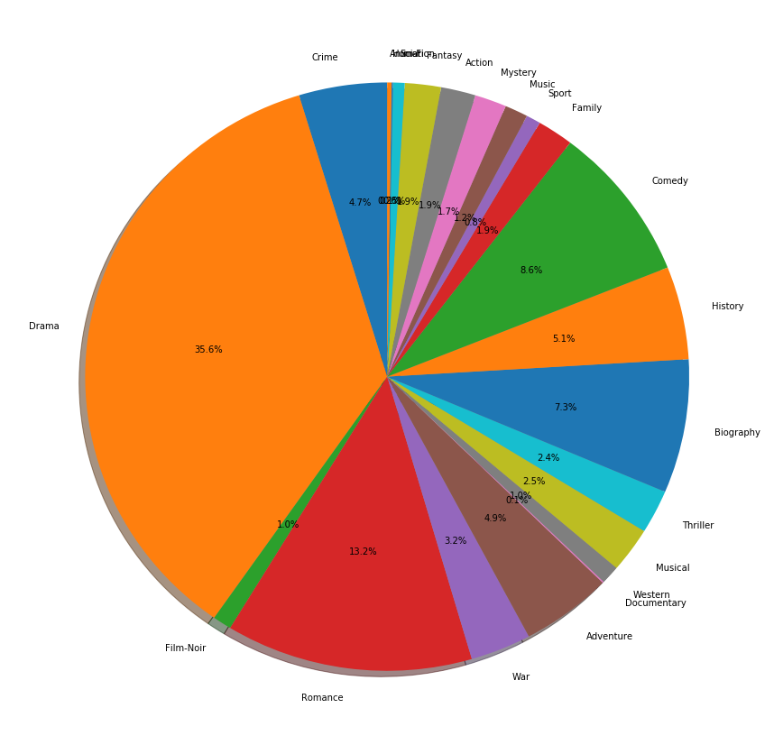

```python
plt.figure(figsize=(15, 15))
plt.pie(list(genre_count.values()), labels=genre_count.keys(), autopct='%1.1f%%', shadow=True, startangle=90)

print('Number of genres : ' + str(len(genre_count.keys())))
print('Total number of genres : ' + str(len(genres_raw)))
```

Let's see how that looks for winners !

```
Number of genres : 18
Total number of genres : 226
```

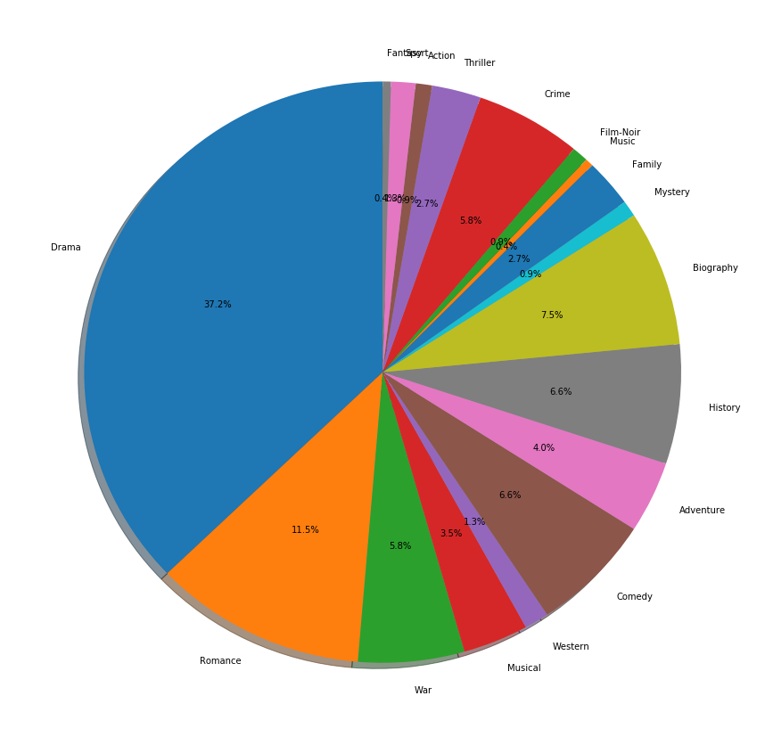

```python
genre_winners = ', '.join([genre for genre in df_picture_winners['Genre']]).split(', ')
genre_winners_count =  Counter(genre_winners)


plt.figure(figsize=(15, 15))
plt.pie(list(genre_winners_count.values()), labels=genre_winners_count.keys(), autopct='%1.1f%%', shadow=True, startangle=90)

print('Number of genres : ' + str(len(genre_winners_count.keys())))
print('Total number of genres : ' + str(len(genre_winners)))
```

Even less genres show up here ! (no sci-fi, documentary, Horror or Animation movie ever won an Oscar).

This, however, doesn't really represent the disparity in Oscar favors, since genres are not mutually exclusive (a Musical can still be Romance and/or Comedy). But it's safe to say that Genres were not created equal !

Lessons :

- Avoid Sci-fi, Documentaries, Horror and Animation movies, even for nominations
- Drama/Romance odds are equivalent to all other genres combined !

### Release Month

(I manually added some missing release date values to the dataset from IMDB)

```python
month_num = {'Jan':1, 'Feb':2, 'Mar':3, 'Apr':4, 'May':5, 'Jun':6, 'Jul':7, 'Aug':8, 'Sep':9, 'Oct':10, 'Nov':11, 'Dec':12}
df_picture['Month'] = [month_num[release.split()[1]] for release in df_picture['Released']]
df_picture_winners['Month'] = [month_num[release.split()[1]] for release in df_picture_winners['Released']]
```

Now .. histograms !

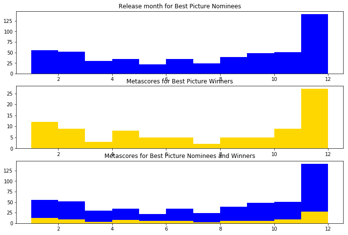

```python
plt.subplot(311)
plt.hist(df_picture['Month'], bins=range(1, 13), color='blue')
plt.title('Release month for Best Picture Nominees')
plt.subplot(312)
plt.hist(df_picture_winners['Month'], bins=range(1, 13), color='gold')
plt.title('Metascores for Best Picture Winners')
plt.subplot(313)
plt.hist(df_picture['Month'], bins=range(1, 13), color='blue')
plt.hist(df_picture_winners['Month'], bins=range(1, 13), color='gold')
plt.title('Metascores for Best Picture Nominees and Winners')
```

November, December, January, February are your best shot.

### Keywords in Plot

```python
plot_words = {}
plot_words_winners = {}

for i, r in df_picture.iterrows():
    plot = r['Plot'].split()
    for word in plot:
        if word in plot_words: plot_words[word] += 1
        else : plot_words[word] = 1
        if r['Winner'] == 1 :
            if word in plot_words_winners: plot_words_winners[word] += 1
            else : plot_words_winners[word] = 1
```

```python
import operator
sorted_words = sorted(plot_words.items(), key=operator.itemgetter(1), reverse=True)
print(', '.join(w[0] for i, w in enumerate(sorted_words) if i < 150))
```

```
a, the, of, to, and, in, his, A, with, is, an, her, for, by, The, on, he, from, who, their, young, as, but, An, In, that, man, woman, life, story, American, love, at, after, two, she, are, family, one, World, War, has, into, him, when, they, help, during, falls, up, while, When, New, lives, new, wif…
```

So, based on top words, we can imagine that a movie that tells the *story* of an *American* *man* and *woman* who are *helping* in *World* *War* *one* as they *struggle* to *find* *love* in *New York* .. sounds exactly like the kind of movies that win Oscars !

```python
sorted_words_winners = sorted(plot_words_winners.items(), key=operator.itemgetter(1), reverse=True)
print(', '.join(w[0] for i, w in enumerate(sorted_words_winners) if i < 150))
```

```
the, a, of, and, to, in, his, A, with, is, an, The, by, for, from, War, he, who, but, young, on, their, World, man, family, love, An, woman, her, story, one, are, New, In, become, at, British, American, that, up, Two, other, life, during, be, Jewish, fall, into, when, against, while, York, King, son…
```

Our man is now a *Jewish officer fighting the Corrupt Catholic Church*, but love and romance are still evident elements !

This was a bit far-fetched, let's now look at the countries that produced the most Oscar nominations and wins ! (The country column is also expressed as CSV)

```python
countries = {}
countries_winners = {}

for i, r in df_picture.iterrows():
    cs = r['Country'].split(', ')
    for c in cs:
        if c in countries: countries[c] += 1
        else : countries[c] = 1
        if r['Winner'] == 1 :
            if c in countries_winners: countries_winners[c] += 1
            else : countries_winners[c] = 1
```

```
Number of countries : 29
```

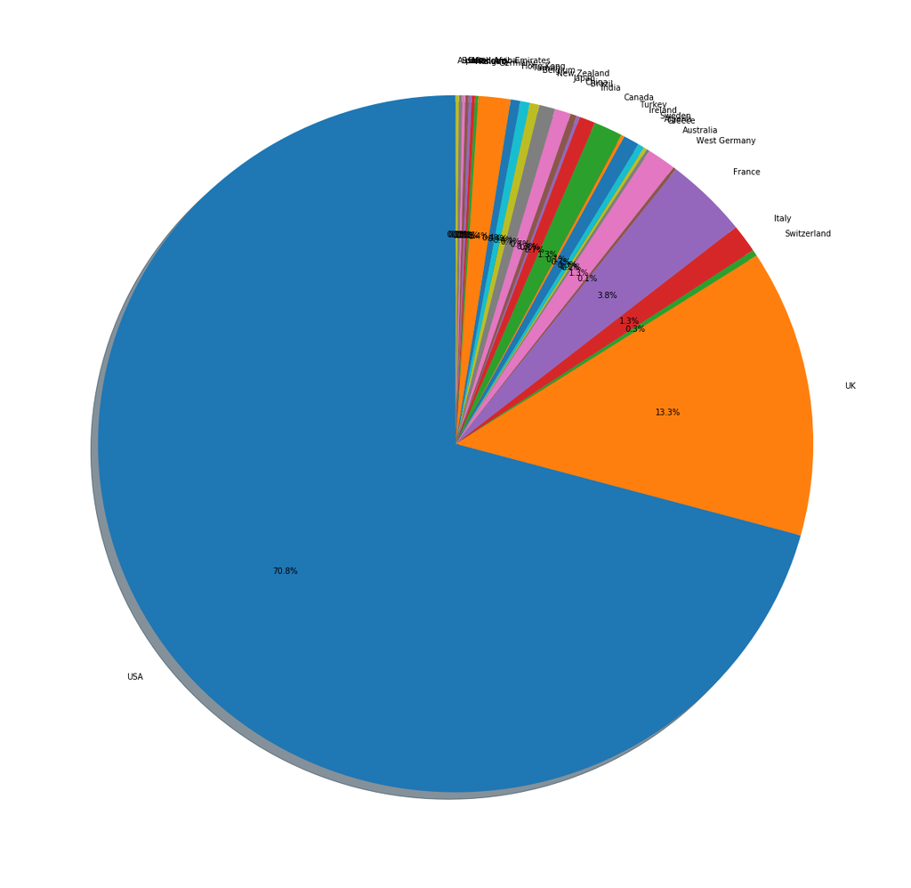

```python
plt.figure(figsize=(20, 20))
plt.pie(list(countries.values()), labels=countries.keys(), autopct='%1.1f%%', shadow=True, startangle=90)

print('Number of countries : ' + str(len(countries)))
```

```
Number of countries : 12 (USA, UK, India, France, Italy, China, Germany, Canada, New Zealand, Hong Kong, Australia, Belgium)
```

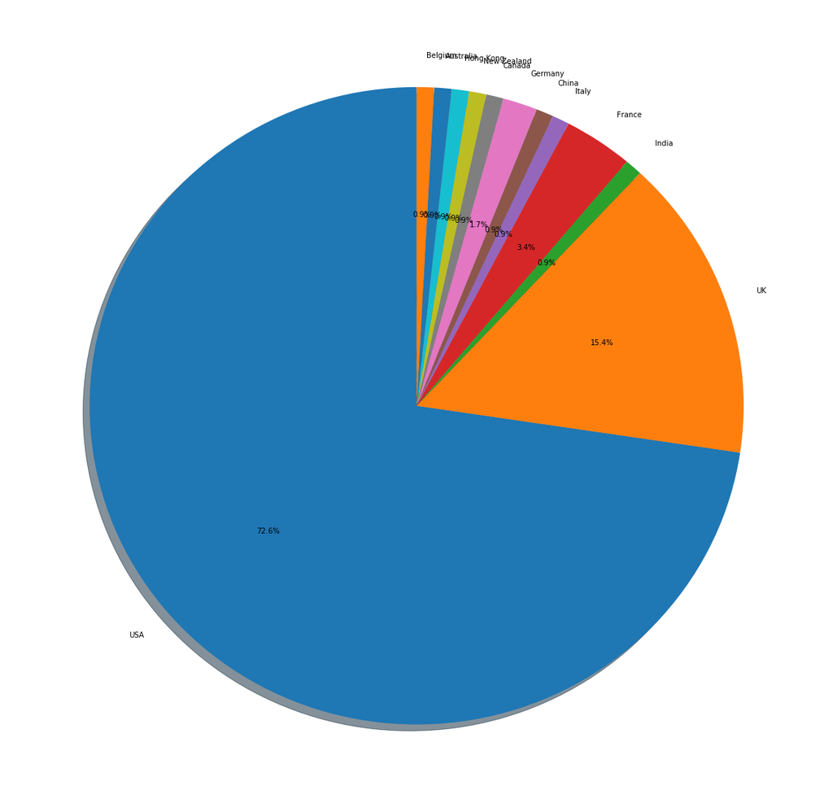

```python
plt.figure(figsize=(20, 20))
plt.pie(list(countries_winners.values()), labels=countries_winners.keys(), autopct='%1.1f%%', shadow=True, startangle=90)

print('Number of countries : ' + str(len(countries_winners)) + ' (' + ', '.join(countries_winners.keys()) + ')')
```

Absolutely no surprise here. "America First !", as they say. It's also no clear whether the wins from other countries came only from American co-productions. Let's check :

```python
df_picture_winners[df_picture_winners['Country'].str.contains('^(?!.*USA).*$')][['Year', 'Name', 'Country']]
```

|  | Year | Name | Country |
| --- | --- | --- | --- |
| 2244 | 1948 | Hamlet | UK |
| 4050 | 1963 | Tom Jones | UK |
| 4419 | 1966 | A Man for All Seasons | UK |
| 4638 | 1968 | Oliver! | UK |
| 6016 | 1981 | Chariots of Fire | UK |

Oh, well. No movie that doesn't involve the US in its production won since 1981, and all those nods were scored by the UK !

Nominations seem to be at least .. more probable :

```python
df_picture[df_picture['Country'].str.contains('^(?!.*USA).*$')].sort_values('Year')[['Year', 'Name', 'Country']]
```

|  | Year | Name | Country |
| --- | --- | --- | --- |
| 243 | 1933 | The Private Life of Henry VIII | UK |
| 485 | 1936 | Romeo and Juliet | UK, Italy |
| 733 | 1938 | The Citadel | UK |
| 735 | 1938 | Grand Illusion | France |
| 737 | 1938 | Pygmalion | UK |
| 875 | 1939 | Goodbye, Mr. Chips | UK |
| 1393 | 1942 | The Invaders | UK |
| 1583 | 1943 | In Which We Serve | UK |
| 2029 | 1946 | Henry V | UK |
| 2136 | 1947 | Great Expectations | UK |
| 2246 | 1948 | The Red Shoes | UK |
| 2244 | 1948 | Hamlet | UK |
| 3563 | 1959 | Room at the Top | UK |
| 3683 | 1960 | Sons and Lovers | UK |
| 4050 | 1963 | Tom Jones | UK |
| 4293 | 1965 | Darling | UK |
| 4418 | 1966 | Alfie | UK |
| 4419 | 1966 | A Man for All Seasons | UK |
| 4638 | 1968 | Oliver! | UK |
| 4640 | 1968 | Romeo and Juliet | UK, Italy |
| 4748 | 1969 | Z | France, Algeria |
| 4744 | 1969 | Anne of the Thousand Days | UK |
| 5061 | 1972 | The Emigrants | Sweden |
| 5163 | 1973 | Cries and Whispers | Sweden |
| 5166 | 1973 | A Touch of Class | UK |
| 5918 | 1980 | Tess | UK, France |
| 6015 | 1981 | Atlantic City | France, Canada |
| 6016 | 1981 | Chariots of Fire | UK |
| 6234 | 1983 | The Dresser | UK |
| 6342 | 1984 | The Killing Fields | UK |
| 6561 | 1986 | A Room with a View | UK |
| 6559 | 1986 | The Mission | UK, France |
| 6877 | 1989 | My Left Foot | Ireland, UK |
| 7320 | 1993 | The Piano | New Zealand, Australia, France |
| 7431 | 1994 | Four Weddings and a Funeral | UK |
| 7551 | 1995 | The Postman (Il Postino) | Italy, France, Belgium |
| 7668 | 1996 | Secrets & Lies | France, UK |
| 7669 | 1996 | Shine | Australia |
| 7898 | 1998 | Elizabeth | UK |
| 7899 | 1998 | Life Is Beautiful | Italy |
| 9531 | 2012 | Amour | Austria, France, Germany |
| 9915 | 2015 | Brooklyn | UK, Canada, Ireland, Belgium |

The rest of the world should get their own Oscars I guess :)

### Box Office Info

US Box Office information is not available for most movies, and for this specific data it's hard to get information about the evolution of said Box Office number before and after the Oscar nomination win (to get access to detailed info about this you need to have, as far as I know, a Pro account in IMDB, which I don't have).

But let's see what this gives us !

```
Slope : 1144131.45424
```

[figure not shown]

```python
x, y = df_picture[df_picture['BoxOffice'] > 0]['Year'], df_picture[df_picture['BoxOffice'] > 0]['BoxOffice']
xw, yw = df_picture_winners[df_picture_winners['BoxOffice']  > 0]['Year'], df_picture_winners[df_picture_winners['BoxOffice'] > 0]['BoxOffice']
m,b = np.polyfit(x, y, 1)

plt.title('Evolution of IMDB rating for Oscar-nominated and winning movies')
plt.plot(x, y, 'b.', xw, yw, 'yo', x, m*x+b, '--k')
print('Slope : ' + str(m))
```

Sadly, information about BO numbers aren't sufficient to draw any conclusions, except for the fact that they seem to be relatively well-spread between small and big movies.

```python
df_picture[df_picture['BoxOffice'] > 0][['Year', 'BoxOffice', 'Name', 'Winner']].sort_values(['BoxOffice'], ascending = False)
```

|  | Year | BoxOffice | Name | Winner |
| --- | --- | --- | --- | --- |
| 9162 | 2009 | 749700000.0 | Avatar | NaN |
| 9291 | 2010 | 414984497.0 | Toy Story 3 | NaN |
| 8468 | 2003 | 364000000.0 | The Lord of the Rings: The Return of the King | 1.0 |
| 8358 | 2002 | 339700000.0 | The Lord of the Rings: The Two Towers | NaN |
| 7430 | 1994 | 330000000.0 | Forrest Gump | 1.0 |
| 8240 | 2001 | 314000000.0 | The Lord of the Rings: The Fellowship of the R... | NaN |
| 9170 | 2009 | 292979556.0 | Up | NaN |
| 9286 | 2010 | 292568851.0 | Inception | NaN |
| 9786 | 2014 | 274377268.0 | American Sniper | NaN |
| 9661 | 2013 | 274084951.0 | Gravity | NaN |
| 9163 | 2009 | 255900000.0 | The Blind Side | NaN |
| 9917 | 2015 | 202313768.0 | The Martian | NaN |
| 9292 | 2010 | 171031347.0 | True Grit | NaN |
| 9412 | 2011 | 169705587.0 | The Help | NaN |
| 9534 | 2012 | 162804648.0 | Django Unchained | NaN |
| 8929 | 2007 | 143380890.0 | Juno | NaN |
| 9047 | 2008 | 141243551.0 | Slumdog Millionaire | 1.0 |
| 9288 | 2010 | 138300000.0 | The King's Speech | 1.0 |
| 9532 | 2012 | 136019448.0 | Argo | 1.0 |
| 8811 | 2006 | 132300000.0 | The Departed | 1.0 |
| 9538 | 2012 | 132088910.0 | Silver Linings Playbook | NaN |
| 9916 | 2015 | 129483877.0 | Mad Max: Fury Road | NaN |
| 9537 | 2012 | 129477447.0 | Lincoln | NaN |
| 9043 | 2008 | 127490802.0 | The Curious Case of Benjamin Button | NaN |
| 8128 | 2000 | 123836420.0 | Traffic | NaN |
| 9167 | 2009 | 120523073.0 | Inglourious Basterds | NaN |
| 8472 | 2003 | 120147445.0 | Seabiscuit | NaN |
| 9164 | 2009 | 115646235.0 | District 9 | NaN |
| 9659 | 2013 | 107100855.0 | Captain Phillips | NaN |
| 9284 | 2010 | 106952327.0 | Black Swan | NaN |
| ... | ... | ... | ... | ... |
| 8239 | 2001 | 35733119.0 | In the Bedroom | NaN |
| 8810 | 2006 | 34237104.0 | Babel | NaN |
| 9046 | 2008 | 34111418.0 | The Reader | NaN |
| 8359 | 2002 | 32519322.0 | The Pianist | NaN |
| 9411 | 2011 | 31836745.0 | Extremely Loud & Incredibly Close | NaN |
| 9045 | 2008 | 31716847.0 | Milk | NaN |
| 8699 | 2005 | 31500000.0 | Good Night, and Good Luck. | NaN |
| 9915 | 2015 | 30459009.0 | Brooklyn | NaN |
| 8697 | 2005 | 28337516.0 | Capote | NaN |
| 9660 | 2013 | 23750994.0 | Dallas Buyers Club | NaN |
| 9287 | 2010 | 20803237.0 | The Kids Are All Right | NaN |
| 9788 | 2014 | 18859617.0 | Boyhood | NaN |
| 9044 | 2008 | 18600000.0 | Frost/Nixon | NaN |
| 9289 | 2010 | 18329466.0 | 127 Hours | NaN |
| 9662 | 2013 | 17901029.0 | Her | NaN |
| 9166 | 2009 | 15700000.0 | The Hurt Locker | 1.0 |
| 9919 | 2015 | 14677654.0 | Room | NaN |
| 8812 | 2006 | 13600000.0 | Letters from Iwo Jima | NaN |
| 9416 | 2011 | 13303319.0 | The Tree of Life | NaN |
| 9533 | 2012 | 12784397.0 | Beasts of the Southern Wild | NaN |
| 9165 | 2009 | 12512069.0 | An Education | NaN |
| 9663 | 2013 | 11348612.0 | Nebraska | NaN |
| 9169 | 2009 | 9190525.0 | A Serious Man | NaN |
| 9531 | 2012 | 6700000.0 | Amour | NaN |
| 9293 | 2010 | 6200000.0 | Winter's Bone | NaN |
| 881 | 1939 | 3840702.0 | The Wizard of Oz | NaN |
| 735 | 1938 | 172885.0 | Grand Illusion | NaN |
| 7207 | 1992 | 157888.0 | Howards End | NaN |
| 4637 | 1968 | 18177.0 | The Lion in Winter | NaN |
| 8586 | 2004 | 14168.0 | Ray | NaN |

98 rows × 4 columns

So the biggest B.O. number holds for *Avatar* (also the highest grossing movie of all times), while the highest grossing Oscar winner is *The Lord of the Rings: The Return of the King*. Lowest grossing Oscar winning movie is *The Hurt Locker*, with only $15M domestically.

This information should be necessarily coupled with information about the actual budget of the movie. For example, Avatar was made on a \$240M budget and made \$750M in the US B.O (a RoI of 3.1), while famously, last year's winner *Moonlight* went to gross \$65M on a \$1.5M (a factor of 43 !). This would be a nice thing to study if we had the appropriate data !

Another thing that movie geeks use to predict the awards output is to correlate it with the awards preceding the Oscars (called Precursors), notably the Guild awards. For example, the Actors' Guild Awards is a good indicator on who's going to win in the acting categories, and so on. Having these correlations in mind would certainly help elevate or eliminate certains outcomes, if only we had the appropriate data !

## 2.2. Actors

But since I don't have that kind of data (actually, I couldn't find *any* dataset about actors except for a complete old-ish dump of IMDB's Mongo database that needed to be set up and queried .. and then again I don't know if information about race and role-types would be there), I decided to collect a little one for one critereon which is age, the only one I could find really. I did so by querying DBPedia, which is the first time I used knowledge from one course (Semantic Web) in another!

So DBPedia contains all sorts of information about all sorts of things in a neat graph structure, with nodes representing either individuals or concepts or just values. These nodes are annotated which makes querying easy and even fun ! So I picked a random Actor (http://dbpedia.org/page/Michael_Fassbender) (who may or may not be my favorite) and scrolled through the kind of annotations he had to see what could be useful for my query. It turns out that actors are annotated with the *dbr:Actor* class from the http://purl.org/linguistics/gold/hypernym ontology (actresses with *dbr:Actress*), and their linked to their Name information with the *foaf:name* relation and their birth date with *dbo:birthDate*. Informations such as nationality and height (could be fun :) ), also can be found, but not for all actors and actresses. This DBPedia source could be mined further for more detailed information if enough time is spent to enumerate all relevant annotations (if you want to know how many *GermanMaleVideoGameActors*, or actors of german descent who also did some voice acting role in a Video Game, were ever nominated or won an Oscar) .. maybe another time !

So let's get that data ! We use SPARQL to query RDF-type data from DBPedia, who are kind enough to actually give direct access to all of their data via a direct interface, for no charge! Here's the link : http://dbpedia.org/sparql

And here's the query (be sure to switch output type to CSV for easier consumption !)

select ?actor ?name ?birthDate ?height ?nationality where { ?actor dbr:Actor; foaf:name ?name; OPTIONAL { ?actor dbo:height ?height. } OPTIONAL { ?actor dbo:birthDate ?birthDate. } OPTIONAL { ?actor dbo:height ?height } FILTER (?v in (dbr:Actor, dbr:Actress)) }

```python
df_actors_raw = pd.read_csv('actors_and_actresses.csv')
```

No to keep up with our tradition of dirty data, the rows that are returned by this query contain a lot of redundancy, for example for Michael Fassbender, we get actually 4 rows, a row is created for every possible combination of values for the given columns :

```python
df_actors_raw[df_actors_raw['name'] == 'Michael Fassbender']
```

|  | actor | name | birthDate | height | nationality |
| --- | --- | --- | --- | --- | --- |
| 3536 | http://dbpedia.org/resource/Michael_Fassbender | Michael Fassbender | 1977-04-02 | 1.524 | http://dbpedia.org/resource/Irish_people |
| 3537 | http://dbpedia.org/resource/Michael_Fassbender | Michael Fassbender | 1977-4-2 | 1.524 | http://dbpedia.org/resource/Irish_people |
| 3538 | http://dbpedia.org/resource/Michael_Fassbender | Michael Fassbender | 1977-04-02 | 1.524 | http://dbpedia.org/resource/German_people |
| 3539 | http://dbpedia.org/resource/Michael_Fassbender | Michael Fassbender | 1977-4-2 | 1.524 | http://dbpedia.org/resource/German_people |

But this is relatively easy to manage, we'll just keep information about the birthYear (it exists as a relation in DBPedia, but it's not specified for many actors, so I took the birthDate instead), and we'll concatenate values for different nationalities into one column :

```python
actor_data = {}
for name in df_actors_raw['name'].unique():
    nationalities = set()
    year, height = 0, 0
    for i, row in df_actors_raw[df_actors_raw['name'] == name].iterrows():
        try:
            if pd.isnull(row['birthDate']) : year = np.NaN
            else:
                try: year = int(row['birthDate'][:4])
                except: year = int(row['birthDate'][4:])
            height = row['height']
            nationalities.add('' if pd.isnull(row['nationality']) else row['nationality'].split('/')[-1].split('_')[0]) #we take the first word from the nationality URI : British_People => British
        except:
            print(row)
            print(row['nationality'])
    actor_data[name] = {'year': year, 'nationalities': ', '.join(nationalities), 'height': height}

print(actor_data['Michael Fassbender'])
```

```
{'year': 1977, 'nationalities': 'German, Irish', 'height': 1.524}
```

```python
df_actors_data = pd.DataFrame.from_dict(actor_data, orient='index')
df_actors_data.sample(10)
```

|  | year | nationalities | height |
| --- | --- | --- | --- |
| Charles Clary | 1873.0 |  | NaN |
| Tony Lip | 1930.0 |  | NaN |
| Don Leonard | 1925.0 |  | NaN |
| Misaki Sekiyama | 1981.0 |  | NaN |
| Raymond Rognoni | 1892.0 |  | NaN |
| Dot Jones | 1964.0 |  | 1.905 |
| Stephen Dartnell | 1931.0 |  | NaN |
| Mitzi Kapture | 1962.0 |  | NaN |
| Emily Perry | 1907.0 |  | NaN |
| Mitchell Lewis | 1880.0 |  | NaN |

Looks good !

Now let's see if this dataset would play nicely with our original Oscar winner and nominees.

```python
[s for s in df['Award_new'].unique() if s.startswith('Act')]
```

```
['Actor in a Leading Role',
 'Actress in a Leading Role',
 'Actor in a Supporting Role',
 'Actress in a Supporting Role']
```

Let's start by selecting the winners and nominees from the original dataframe. Then we'll try to join each of the cells with the new values from DBPedia.

```python
df_actors = df[df['Award_new'].str.startswith('Act')].copy()
df_actors[:10]
```

|  | Year | Ceremony | Award | Winner | Name | Film | Award_new | Year_new |
| --- | --- | --- | --- | --- | --- | --- | --- | --- |
| 0 | 1927/1928 | 1 | Actor | NaN | Richard Barthelmess | The Noose | Actor in a Leading Role | 1928 |
| 1 | 1927/1928 | 1 | Actor | 1.0 | Emil Jannings | The Last Command | Actor in a Leading Role | 1928 |
| 2 | 1927/1928 | 1 | Actress | NaN | Louise Dresser | A Ship Comes In | Actress in a Leading Role | 1928 |
| 3 | 1927/1928 | 1 | Actress | 1.0 | Janet Gaynor | 7th Heaven | Actress in a Leading Role | 1928 |
| 4 | 1927/1928 | 1 | Actress | NaN | Gloria Swanson | Sadie Thompson | Actress in a Leading Role | 1928 |
| 35 | 1928/1929 | 2 | Actor | NaN | George Bancroft | Thunderbolt | Actor in a Leading Role | 1929 |
| 36 | 1928/1929 | 2 | Actor | 1.0 | Warner Baxter | In Old Arizona | Actor in a Leading Role | 1929 |
| 37 | 1928/1929 | 2 | Actor | NaN | Chester Morris | Alibi | Actor in a Leading Role | 1929 |
| 38 | 1928/1929 | 2 | Actor | NaN | Paul Muni | The Valiant | Actor in a Leading Role | 1929 |
| 39 | 1928/1929 | 2 | Actor | NaN | Lewis Stone | The Patriot | Actor in a Leading Role | 1929 |

Let's how many actors and actresses are actually listed on DBPedia as such :

```python
counter = 0
for name in df_actors['Name'].unique():
    if name in actor_data:
        counter += 1
    else:
        print(name, end=', ')
print("# of actors found in DBPedia : " + str(counter) + '/' + str(len(df_actors['Name'].unique())))
```

```
Emil Jannings, Janet Gaynor, Gloria Swanson, George Bancroft, Warner Baxter, Chester Morris, Paul Muni, Lewis Stone, Ruth Chatterton, Bessie Love, Mary Pickford, George Arliss, Wallace Beery, Maurice Chevalier, Ronald Colman, Lawrence Tibbett, Greta Garbo, Norma Shearer, Lionel Barrymore, Jackie Coo…
```

127/906 .. That's .. discouraging to say the least.

A quick lookaround and I found out that different actors are labeled under different categories (dbr:Actor is the one I used for my query, but there is also dbr:Actress, umbel-rc:Actor ..), but most, and I mean **most**, are just not returned by the query (for example, *Frances McDormand* is indeed flagged as a dbr:Actress, but the query to list all dbr:Actress nodes simply doesn't return her).

I generated the query body here :

```python
for name in df_actors['Name'].unique()[:10] :
    print('"'+name+'"@en', end=', ')
```

```
"Richard Barthelmess"@en, "Emil Jannings"@en, "Louise Dresser"@en, "Janet Gaynor"@en, "Gloria Swanson"@en, "George Bancroft"@en, "Warner Baxter"@en, "Chester Morris"@en, "Paul Muni"@en, "Lewis Stone"@en,
```

And the query looks like this : (each time the list is modified and a CSV file is downloaded)

select ?actor ?name ?birthDate ?height ?nationality where { ?actor ?v; foaf:name ?name. OPTIONAL { ?actor dbo:height ?height. } OPTIONAL { ?actor dbo:birthDate ?birthDate. ?birthDate rdf:type xsd:date} OPTIONAL { ?actor dbo:birthDate ?birthDate. } OPTIONAL { ?actor dbo:nationality ?nationality. } FILTER (?name IN ("Richard Barthelmess"@en, "Emil Jannings"@en, "Louise Dresser"@en, "Janet Gaynor"@en, "Gloria Swanson"@en, "George Bancroft"@en, "Warner Baxter"@en, "Chester Morris"@en, "Paul Muni"@en, "Lewis Stone"@en ..)) FILTER (?v in (dbr:Actor, dbr:Actress)) }

Without adding the (Actor, Actress) restriction, the DBPedia returns all people with similar names but different professions. So I opted for the restriction which limits the results (for actors who are not annotated) but we at least get accurate results. I got 651/906 actors, I wanted a little bit more to have statically significat results.

I dropped the Actor annotation, got back some results and manually removed non-actors (the ones it says so on their URL, such as http://dbpedia.org/resource/Kevin_McCarthy_(director)), which amounted to this :

```python
df_actors_raw = pd.read_csv('actors_and_actresses_v2.csv')
```

```python
actor_data = {}
for name in df_actors_raw['name'].unique():
    nationalities = set()
    year, height = 0, 0
    for i, row in df_actors_raw[df_actors_raw['name'] == name].iterrows():
        try:
            if pd.isnull(row['birthDate']) : year = np.NaN
            else:
                try: year = int(row['birthDate'][:4])
                except: year = int(row['birthDate'][4:])
            height = row['height']
            nationalities.add('' if pd.isnull(row['nationality']) else row['nationality'].split('/')[-1].split('_')[0]) #we take the first word from the nationality URI : British_People => British
        except:
            print(row)
            print(row['nationality'])
    actor_data[name] = {'year': year, 'nationalities': ', '.join(nationalities), 'height': height}

print(actor_data['Michael Fassbender'])
```

```
{'year': 1977, 'nationalities': 'German, Irish', 'height': 1.524}
```

```python
counter = 0
for name in df_actors['Name'].unique():
    if name in actor_data:
        counter += 1
    else:
        print('"'+name+'"@en', end=', ')
print("# of actors found in DBPedia : " + str(counter) + '/' + str(len(df_actors['Name'].unique())))
```

```
"Brandon De Wilde"@en, "Geraldine Page"@en, "Arthur O'Connell"@en, "Sir Laurence Olivier"@en,"Peter O'Toole"@en, "Anouk Aimee"@en, "Jocelyne Lagarde"@en, "Topol"@en, "Howard E. Rollins, Jr."@en, "Louis Gossett, Jr."@en, "Noriyuki 'Pat' Morita"@en, "Daniel Day Lewis"@en, "Gerard Depardieu"@en,"Robert…
```

Big success ! Now with only 17 entries left, we're one query away from recovering the entire DBpedia records for these actors. Most of these misfinds are due to some quirks in naming (accents, initials, "Sir", "jr.", dropping last names, ..) except for Jocelyne Legarde who just didn't exist in the DBPedia at all so I had to look her birthdate in Google.

```python
df_actors_raw = pd.read_csv('actors_and_actresses_v3.csv')

actor_data = {}
for name in df_actors_raw['name'].unique():
    nationalities = set()
    year, height = 0, 0
    for i, row in df_actors_raw[df_actors_raw['name'] == name].iterrows():
        try:
            if pd.isnull(row['birthDate']) : year = np.NaN
            else:
                try: year = int(row['birthDate'][:4])
                except: year = int(row['birthDate'][4:])
            height = row['height']
            nationalities.add('' if pd.isnull(row['nationality']) else row['nationality'].split('/')[-1].split('_')[0]) #we take the first word from the nationality URI : British_People => British
        except:
            print(row)
            print(row['nationality'])
    actor_data[name] = {'birthYear': year, 'nationalities': ', '.join(nationalities), 'height': height}

counter = 0
for name in df_actors['Name'].unique():
    if name in actor_data:
        counter += 1
    else:
        print('"'+name+'"@en', end=', ')

print("# of actors found in DBPedia : " + str(counter) + '/' + str(len(df_actors['Name'].unique())))
```

```
# of actors found in DBPedia : 906/906
```

Finally, let's merge the data with the awards dataframe :

```python
df_actors['birthYear'] = np.NaN
df_actors['nationalities'] = ""
df_actors['height'] = np.NaN
```

```python
for column in ['birthYear', 'nationalities', 'height'] :
    df_actors[column] = df_actors['Name'].map(dict((m, actor_data[m][column] if column in actor_data[m] else 0) for m in actor_data))
```

```python
df_actors[:10]
```

|  | Year | Ceremony | Award | Winner | Name | Film | Award_new | Year_new | birthYear | nationalities | height |
| --- | --- | --- | --- | --- | --- | --- | --- | --- | --- | --- | --- |
| 0 | 1927/1928 | 1 | Actor | NaN | Richard Barthelmess | The Noose | Actor in a Leading Role | 1928 | 1895 |  | NaN |
| 1 | 1927/1928 | 1 | Actor | 1.0 | Emil Jannings | The Last Command | Actor in a Leading Role | 1928 | 1884 |  | NaN |
| 2 | 1927/1928 | 1 | Actress | NaN | Louise Dresser | A Ship Comes In | Actress in a Leading Role | 1928 | 1878 |  | NaN |
| 3 | 1927/1928 | 1 | Actress | 1.0 | Janet Gaynor | 7th Heaven | Actress in a Leading Role | 1928 | 1906 |  | NaN |
| 4 | 1927/1928 | 1 | Actress | NaN | Gloria Swanson | Sadie Thompson | Actress in a Leading Role | 1928 | 1899 |  | NaN |
| 35 | 1928/1929 | 2 | Actor | NaN | George Bancroft | Thunderbolt | Actor in a Leading Role | 1929 | 1882 | United | NaN |
| 36 | 1928/1929 | 2 | Actor | 1.0 | Warner Baxter | In Old Arizona | Actor in a Leading Role | 1929 | 1889 |  | NaN |
| 37 | 1928/1929 | 2 | Actor | NaN | Chester Morris | Alibi | Actor in a Leading Role | 1929 | 1901 |  | NaN |
| 38 | 1928/1929 | 2 | Actor | NaN | Paul Muni | The Valiant | Actor in a Leading Role | 1929 | 1895 |  | NaN |
| 39 | 1928/1929 | 2 | Actor | NaN | Lewis Stone | The Patriot | Actor in a Leading Role | 1929 | 1879 |  | NaN |

[figure not shown]

Let's RUMBLE !

### #GiveLeoHisDamnOscar

Last year, there was a lot of compaining for Leonardo DiCaprio to win his Oscar, because he was nominated 4 times before, only to fall short every single time. He had to eat actual raw bison liver to finally get the biggest recognition an actor could wish for : winning his damn oscar. Now is Leo the unluckiest of them all ? Let's see the history of some unlucky people who may need some compaining as well: (aka people who were nominated several times yet never won) :

```python
# I'm going to need this
df_actors['Age'] = (df_actors['Year_new'].astype(int) - df_actors['birthYear']).astype(int)
```

```python
count = 1
for name in df_actors['Name'].unique():
    # To know whether someone never won, it suffices to count the sum of the "Winner" column, which should add up to 0 for "No Win"
    if len(df_actors[df_actors['Name'] == name]) > 3 and sum(df_actors[df_actors['Name'] == name]['Winner'].fillna(0)) == 0:
        print(str(count) + '. ' + name)
        count += 1
        year = df_actors[df_actors['Name'] == name]['birthYear'].iloc[0]
        for i, entry in df_actors[df_actors['Name'] == name].iterrows():
            print(str(entry['Year_new']) + '\t' + entry['Award_new'] + '  \t(age : ' + str(entry['Age']) +') : ' + ('Winner' if entry['Winner'] == 1.0 else 'Nominee'))
```

```
1. Irene Dunne
1931	Actress in a Leading Role  	(age : 33) : Nominee
1936	Actress in a Leading Role  	(age : 38) : Nominee
1937	Actress in a Leading Role  	(age : 39) : Nominee
1939	Actress in a Leading Role  	(age : 41) : Nominee
1948	Actress in a Leading Role  	(age : 50) : Nominee
2. Charles Boyer
1937	Actor in a Leading Role  	(age : 38) : Nominee
1938	Actor in a Leading Role  	(age : 39) : Nominee
1944	Actor in a Leading Role  	(age : 45) : Nominee
1961	Actor in a Leading Role  	(age : 62) : Nominee
3. Barbara Stanwyck
1937	Actress in a Leading Role  	(age : 30) : Nominee
1941	Actress in a Leading Role  	(age : 34) : Nominee
1944	Actress in a Leading Role  	(age : 37) : Nominee
1948	Actress in a Leading Role  	(age : 41) : Nominee
4. Mickey Rooney
1939	Actor in a Leading Role  	(age : 19) : Nominee
1943	Actor in a Leading Role  	(age : 23) : Nominee
1956	Actor in a Supporting Role  	(age : 36) : Nominee
1979	Actor in a Supporting Role  	(age : 59) : Nominee
5. Claude Rains
1939	Actor in a Supporting Role  	(age : 50) : Nominee
1943	Actor in a Supporting Role  	(age : 54) : Nominee
1944	Actor in a Supporting Role  	(age : 55) : Nominee
1946	Actor in a Supporting Role  	(age : 57) : Nominee
6. Rosalind Russell
1942	Actress in a Leading Role  	(age : 35) : Nominee
1946	Actress in a Leading Role  	(age : 39) : Nominee
1947	Actress in a Leading Role  	(age : 40) : Nominee
1958	Actress in a Leading Role  	(age : 51) : Nominee
7. Agnes Moorehead
1942	Actress in a Supporting Role  	(age : 42) : Nominee
1944	Actress in a Supporting Role  	(age : 44) : Nominee
1948	Actress in a Supporting Role  	(age : 48) : Nominee
1964	Actress in a Supporting Role  	(age : 64) : Nominee
8. Montgomery Clift
1948	Actor in a Leading Role  	(age : 28) : Nominee
1951	Actor in a Leading Role  	(age : 31) : Nominee
1953	Actor in a Leading Role  	(age : 33) : Nominee
```

[output cut: 67 more lines]

```
1990	Actress in a Supporting Role  	(age : 32) : Nominee
1999	Actress in a Leading Role  	(age : 41) : Nominee
2004	Actress in a Leading Role  	(age : 46) : Nominee
2010	Actress in a Leading Role  	(age : 52) : Nominee
20. Ed Harris
1995	Actor in a Supporting Role  	(age : 45) : Nominee
1998	Actor in a Supporting Role  	(age : 48) : Nominee
2000	Actor in a Leading Role  	(age : 50) : Nominee
2002	Actor in a Supporting Role  	(age : 52) : Nominee
21. Amy Adams
2005	Actress in a Supporting Role  	(age : 31) : Nominee
2008	Actress in a Supporting Role  	(age : 34) : Nominee
2010	Actress in a Supporting Role  	(age : 36) : Nominee
2012	Actress in a Supporting Role  	(age : 38) : Nominee
2013	Actress in a Leading Role  	(age : 39) : Nominee
```

So, there are 21 people thoughout the history of the Oscars who were nominated at least 4 times but never won.

I mean look at Peter O'Tool, dude was nominated a freaking 8 TIMES (all of which in LEADING, which is substantially harder to win than Supporting actor), never won one (unless you count the Honorary Achievement Award which is given to actors who have made an impact on modern cinema without ever winning an Oscar, Jackie Chan is one such winner).

How about people who actually won after a streak of unfruitful nominations ? (Like Leo)

```python
count = 1
for name in df_actors['Name'].unique():
    # To know when someone won their first oscar, we can get the index of the first 1 in the "Winner" column
    wins = df_actors[df_actors['Name'] == name]['Winner'].fillna(0)
    if len(df_actors[df_actors['Name'] == name]) > 3 and sum(wins) == 0:
        print(str(count) + '. ' + name)
        count += 1
        year = df_actors[df_actors['Name'] == name]['birthYear'].iloc[0]
        for i, entry in df_actors[df_actors['Name'] == name].iterrows():
            print(str(entry['Year_new']) + '\t' + entry['Award_new'] + '  \t(age : ' + str(entry['Age']) +') : ' + ('Winner' if entry['Winner'] == 1.0 else 'Nominee'))
```

```
1. Irene Dunne
1931	Actress in a Leading Role  	(age : 33) : Nominee
1936	Actress in a Leading Role  	(age : 38) : Nominee
1937	Actress in a Leading Role  	(age : 39) : Nominee
1939	Actress in a Leading Role  	(age : 41) : Nominee
1948	Actress in a Leading Role  	(age : 50) : Nominee
2. Charles Boyer
1937	Actor in a Leading Role  	(age : 38) : Nominee
1938	Actor in a Leading Role  	(age : 39) : Nominee
1944	Actor in a Leading Role  	(age : 45) : Nominee
1961	Actor in a Leading Role  	(age : 62) : Nominee
3. Barbara Stanwyck
1937	Actress in a Leading Role  	(age : 30) : Nominee
1941	Actress in a Leading Role  	(age : 34) : Nominee
1944	Actress in a Leading Role  	(age : 37) : Nominee
1948	Actress in a Leading Role  	(age : 41) : Nominee
4. Mickey Rooney
1939	Actor in a Leading Role  	(age : 19) : Nominee
1943	Actor in a Leading Role  	(age : 23) : Nominee
1956	Actor in a Supporting Role  	(age : 36) : Nominee
1979	Actor in a Supporting Role  	(age : 59) : Nominee
5. Claude Rains
1939	Actor in a Supporting Role  	(age : 50) : Nominee
1943	Actor in a Supporting Role  	(age : 54) : Nominee
1944	Actor in a Supporting Role  	(age : 55) : Nominee
1946	Actor in a Supporting Role  	(age : 57) : Nominee
6. Rosalind Russell
1942	Actress in a Leading Role  	(age : 35) : Nominee
1946	Actress in a Leading Role  	(age : 39) : Nominee
1947	Actress in a Leading Role  	(age : 40) : Nominee
1958	Actress in a Leading Role  	(age : 51) : Nominee
7. Agnes Moorehead
1942	Actress in a Supporting Role  	(age : 42) : Nominee
1944	Actress in a Supporting Role  	(age : 44) : Nominee
1948	Actress in a Supporting Role  	(age : 48) : Nominee
1964	Actress in a Supporting Role  	(age : 64) : Nominee
8. Montgomery Clift
1948	Actor in a Leading Role  	(age : 28) : Nominee
1951	Actor in a Leading Role  	(age : 31) : Nominee
1953	Actor in a Leading Role  	(age : 33) : Nominee
```

[output cut: 67 more lines]

```
1990	Actress in a Supporting Role  	(age : 32) : Nominee
1999	Actress in a Leading Role  	(age : 41) : Nominee
2004	Actress in a Leading Role  	(age : 46) : Nominee
2010	Actress in a Leading Role  	(age : 52) : Nominee
20. Ed Harris
1995	Actor in a Supporting Role  	(age : 45) : Nominee
1998	Actor in a Supporting Role  	(age : 48) : Nominee
2000	Actor in a Leading Role  	(age : 50) : Nominee
2002	Actor in a Supporting Role  	(age : 52) : Nominee
21. Amy Adams
2005	Actress in a Supporting Role  	(age : 31) : Nominee
2008	Actress in a Supporting Role  	(age : 34) : Nominee
2010	Actress in a Supporting Role  	(age : 36) : Nominee
2012	Actress in a Supporting Role  	(age : 38) : Nominee
2013	Actress in a Leading Role  	(age : 39) : Nominee
```

Let's see how many oscars nominations does it take to win one :

```python
num_losses_before_win = dict()
for name in df_actors['Name'].unique():
    # To know whether someone never won, it suffices to count the sum of the "Winner" column, which should add up to 0 for "No Win"
    wins = df_actors[df_actors['Name'] == name]['Winner'].fillna(0).nonzero()[0]
    if len(wins) > 0 :
        if min(wins) in num_losses_before_win : num_losses_before_win[min(wins)] += 1
        else: num_losses_before_win[min(wins)] = 1

num_losses_before_win
```

```
{0: 185, 1: 65, 2: 18, 3: 13, 4: 8, 5: 1, 6: 2, 7: 1}
```

```python
num_losses_without_win = dict()
for name in df_actors['Name'].unique():
    # To know whether someone never won, it suffices to count the sum of the "Winner" column, which should add up to 0 for "No Win"
    noms = df_actors[df_actors['Name'] == name]['Winner'].fillna(0)
    if sum(noms) == 0 :
        if len(noms) in num_losses_without_win : num_losses_without_win[len(noms)] += 1
        else: num_losses_without_win[len(noms)] = 1

num_losses_without_win
```

```
{1: 465, 2: 97, 3: 30, 4: 12, 5: 4, 6: 3, 7: 1, 8: 1}
```

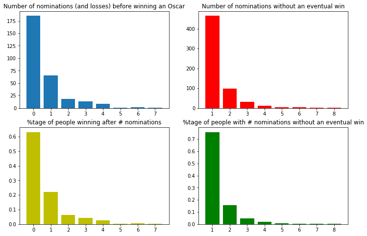

```python
plt.subplot(221)
plt.bar(range(0,8), [num_losses_before_win[k] for k in range(0,8)])
plt.title('Number of nominations (and losses) before winning an Oscar')
plt.subplot(222)
plt.bar(range(1,9), [num_losses_without_win[k] for k in range(1,9)], color='r')
plt.title('Number of nominations without an eventual win')

plt.subplot(223)
plt.bar(range(0,8), [num_losses_before_win[k]/sum(num_losses_before_win.values()) for k in range(0,8)], color='y')
plt.title('%tage of people winning after # nominations')
plt.subplot(224)
plt.bar(range(1,9), [num_losses_without_win[k]/sum(num_losses_without_win.values()) for k in range(1,9)], color='g')
plt.title('%tage of people with # nominations without an eventual win')
```

So 185 actors, that's about 63%, got their first Oscar on their first nomination, lucky bunch ! About a third of that (20%) get their oscar on their second nomination, and it keeps dwindling and dwindling.

The number of nominations without win shows us that a lot of people (almost 80%) get their one nomination and never see their name in the award broadcast again, which means that new having one nomination doesn't correlate well with having eventually more nominations (only 20% of nominees get to be nominated a second time or more : and they have an almost equal chance on winning on their second nomination (around 20% for both graphs).

In general, and countrary to popular belief, having multiple nominations doesn't realistically increase your chances of winning again ! (graphs for winning after X nominations and not winning after X nominations have the same shape !)

Now let's take a look at people who went on a losing streak until they won their first oscar (who lost at least 4 times before winning, DiCaprio-style)

```python
count = 1
for name in df_actors['Name'].unique():
    # To know whether someone never won, it suffices to count the sum of the "Winner" column, which should add up to 0 for "No Win"
    wins = df_actors[df_actors['Name'] == name]['Winner'].fillna(0).nonzero()[0]
    if len(df_actors[df_actors['Name'] == name]) > 3 and len(wins) > 0 and min(wins) > 3:
        print(str(count) + '. ' + name)
        count += 1
        year = df_actors[df_actors['Name'] == name]['birthYear'].iloc[0]
        for i, entry in df_actors[df_actors['Name'] == name].iterrows():
            print(str(entry['Year_new']) + '\t' + entry['Award_new'] + '  \t(age : ' + str(int(int(entry['Year_new'])- year)) +') : ' + ('Winner' if entry['Winner'] == 1.0 else 'Nominee'))
```

```
1. Gregory Peck
1945	Actor in a Leading Role  	(age : 29) : Nominee
1946	Actor in a Leading Role  	(age : 30) : Nominee
1947	Actor in a Leading Role  	(age : 31) : Nominee
1949	Actor in a Leading Role  	(age : 33) : Nominee
1962	Actor in a Leading Role  	(age : 46) : Winner
2. Susan Hayward
1947	Actress in a Leading Role  	(age : 30) : Nominee
1949	Actress in a Leading Role  	(age : 32) : Nominee
1952	Actress in a Leading Role  	(age : 35) : Nominee
1955	Actress in a Leading Role  	(age : 38) : Nominee
1958	Actress in a Leading Role  	(age : 41) : Winner
3. Geraldine Page
1953	Actress in a Supporting Role  	(age : 29) : Nominee
1961	Actress in a Leading Role  	(age : 37) : Nominee
1962	Actress in a Leading Role  	(age : 38) : Nominee
1966	Actress in a Supporting Role  	(age : 42) : Nominee
1972	Actress in a Supporting Role  	(age : 48) : Nominee
1978	Actress in a Leading Role  	(age : 54) : Nominee
1984	Actress in a Supporting Role  	(age : 60) : Nominee
1985	Actress in a Leading Role  	(age : 61) : Winner
4. Paul Newman
1958	Actor in a Leading Role  	(age : 33) : Nominee
1961	Actor in a Leading Role  	(age : 36) : Nominee
1963	Actor in a Leading Role  	(age : 38) : Nominee
1967	Actor in a Leading Role  	(age : 42) : Nominee
1981	Actor in a Leading Role  	(age : 56) : Nominee
1982	Actor in a Leading Role  	(age : 57) : Nominee
1986	Actor in a Leading Role  	(age : 61) : Winner
1994	Actor in a Leading Role  	(age : 69) : Nominee
2002	Actor in a Supporting Role  	(age : 77) : Nominee
5. Shirley MacLaine
1958	Actress in a Leading Role  	(age : 24) : Nominee
1960	Actress in a Leading Role  	(age : 26) : Nominee
1963	Actress in a Leading Role  	(age : 29) : Nominee
1977	Actress in a Leading Role  	(age : 43) : Nominee
1983	Actress in a Leading Role  	(age : 49) : Winner
6. Jack Nicholson
1969	Actor in a Supporting Role  	(age : 32) : Nominee
1970	Actor in a Leading Role  	(age : 33) : Nominee
```

[output cut: 37 more lines]

```
2015	Actor in a Leading Role  	(age : 41) : Winner
11. Kate Winslet
1995	Actress in a Supporting Role  	(age : 20) : Nominee
1997	Actress in a Leading Role  	(age : 22) : Nominee
2001	Actress in a Supporting Role  	(age : 26) : Nominee
2004	Actress in a Leading Role  	(age : 29) : Nominee
2006	Actress in a Leading Role  	(age : 31) : Nominee
2008	Actress in a Leading Role  	(age : 33) : Winner
2015	Actress in a Supporting Role  	(age : 40) : Nominee
12. Julianne Moore
1997	Actress in a Supporting Role  	(age : 37) : Nominee
1999	Actress in a Leading Role  	(age : 39) : Nominee
2002	Actress in a Leading Role  	(age : 42) : Nominee
2002	Actress in a Supporting Role  	(age : 42) : Nominee
2014	Actress in a Leading Role  	(age : 54) : Winner
```

Now look at these unlucky people ! Geraldine Page had to be nominated an unholy **7** times to win, finally, at age 61 her first and only oscar. Paul Neuman and Al Pacino ? 6 times. Kate Winslet ? 5.

In the Oscar game, it's never too late. Or is it ? Let's see how age affects one's chances of winning.

### Age and Odds

After all the scraping we did on DBPedia, it's finally time to use the information about Oscar nominations and Age.

Let's start by some general statistics :

```python
df_actors['Age'].describe()
```

```
count    1668.000000
mean       41.559952
std        13.415178
min         8.000000
25%        32.000000
50%        39.000000
75%        49.000000
max        87.000000
Name: Age, dtype: float64
```

So, nominations span pretty much across the age spectrum from as early as 8 to a late 87 ! The average age across categories is 41.5, with a significant spread of 13.5 years.

As we did with movies, let's compare with winners :

```python
df_actors_winners = df_actors[ df_actors['Winner'] == 1]
df_actors_winners['Age'].describe()
```

```
count    339.000000
mean      42.168142
std       13.181641
min       10.000000
25%       33.000000
50%       41.000000
75%       48.500000
max       82.000000
Name: Age, dtype: float64
```

The distribution moves a bit but we still look at an average age of 42 and a spread of 13.2

Let's look at distributions :

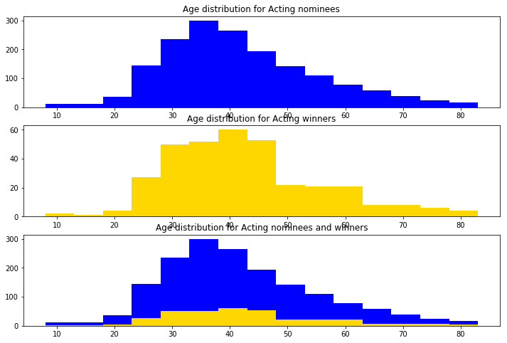

```python
plt.subplot(311)
plt.hist(df_actors['Age'], bins=range(8, 88, 5), color='blue')
plt.title('Age distribution for Acting nominees')
plt.subplot(312)
plt.hist(df_actors_winners['Age'], bins=range(8, 88, 5), color='gold')
plt.title('Age distribution for Acting winners')
plt.subplot(313)
plt.hist(df_actors['Age'], bins=range(8, 88, 5), color='blue')
plt.hist(df_actors_winners['Age'], bins=range(8, 88, 5), color='gold')
plt.title('Age distribution for Acting nominees and winners')
```

A couple of noticeable things : nominees fall into this nice, almost normal distribution (slightly tilted towards the old folks), with pretty much every age group covered and a concentration around 38. Winners, however, get a sharper penalty after the age of 50-ish, then once again after 60-ish (clear in the second graph).

Now this is all good and peachy, but as the story goes, this doesn't hold true when you go further into every categories, something shady and sinister should appear..

### Cross-sections :

When talking in general, we can miss some interesting details about what's happening. There is an information they we didn't use yet with is the distribution among categories (Actor and Actress, Lead and Supporing). Let's get a first general idea :

(I'll be using pink-ish color for Female categories and blue-ish ones for the Male ones, just to make graphs easier to digest)

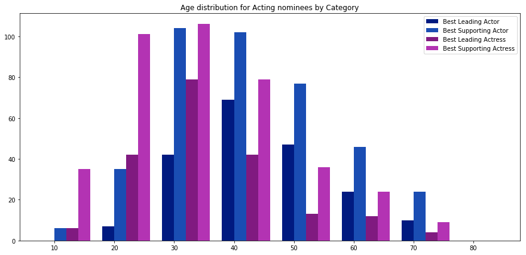

```python
# I used 10 as a bucket size because it faily represents "age groups" 8-18 for teens, 18-28 for young adults ..
bins = list(range(8, 88, 10))
w = 2
plt.figure(figsize=(15, 7))
plt.hist(df_actors[df_actors['Award'] == 'Actor in a Leading Role']['Age'], bins=bins, width=w, color=[0, 0.1, 0.5], label='Best Leading Actor')
plt.hist(df_actors[df_actors['Award'] == 'Actor in a Supporting Role']['Age'], bins=[x+w for x in bins], width=w, color=[0.1, 0.3, 0.7], label='Best Supporting Actor')
plt.hist(df_actors[df_actors['Award'] == 'Actress in a Leading Role']['Age'], bins=[x+2*w for x in bins], width=w, color=[0.5, 0.1, 0.5], label='Best Leading Actress')
plt.hist(df_actors[df_actors['Award'] == 'Actress in a Supporting Role']['Age'], bins=[x+3*w for x in bins], width=w, color=[0.7, 0.2, 0.7], label='Best Supporting Actress')
plt.legend()
plt.title('Age distribution for Acting nominees by Category')
```

Bingo ! Look at all those beautiful disparities !

In an ideal world, these bars should be equal, or at least close, across age groups. What we see, however, is that age does vary from category to the other. Let's make that even clearer :

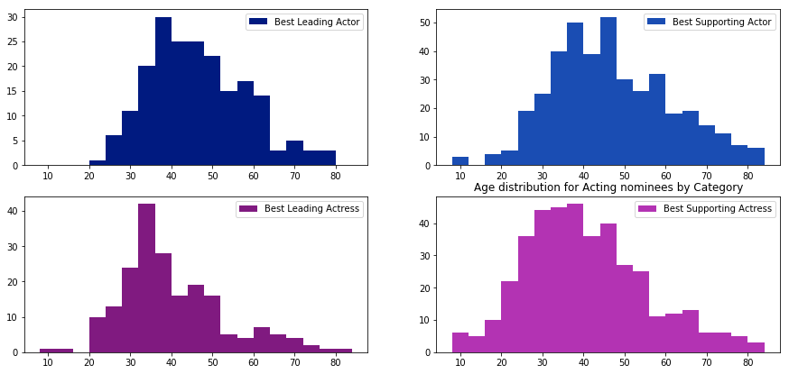

```python
bins = list(range(8, 88, 4))
w = 2
plt.figure(figsize=(15, 7))
plt.subplot(221)
y1 = plt.hist(df_actors[df_actors['Award'] == 'Actor in a Leading Role']['Age'], bins=bins, color=[0, 0.1, 0.5], label='Best Leading Actor')
plt.legend()
plt.subplot(222)
y2 = plt.hist(df_actors[df_actors['Award'] == 'Actor in a Supporting Role']['Age'], bins=bins, color=[0.1, 0.3, 0.7], label='Best Supporting Actor')
plt.legend()
plt.subplot(223)
y3 = plt.hist(df_actors[df_actors['Award'] == 'Actress in a Leading Role']['Age'], bins=bins, color=[0.5, 0.1, 0.5], label='Best Leading Actress')
plt.legend()
plt.subplot(224)
y4 = plt.hist(df_actors[df_actors['Award'] == 'Actress in a Supporting Role']['Age'], bins=bins, color=[0.7, 0.2, 0.7], label='Best Supporting Actress')
plt.legend()
plt.title('Age distribution for Acting nominees by Category')
```

```python
print('Actor in a Leading Role')
print(df_actors[df_actors['Award'] == 'Actor in a Leading Role']['Age'].describe())

print('Actor in a Supporting Role')
print(df_actors[df_actors['Award'] == 'Actor in a Supporting Role']['Age'].describe())

print('Actress in a Leading Role')
print(df_actors[df_actors['Award'] == 'Actress in a Leading Role']['Age'].describe())

print('Actress in a Supporting Role')
print(df_actors[df_actors['Award'] == 'Actress in a Supporting Role']['Age'].describe())
```

```
Actor in a Leading Role
count    200.000000
mean      45.935000
std       11.602754
min       23.000000
25%       38.000000
50%       44.500000
75%       54.000000
max       79.000000
Name: Age, dtype: float64
Actor in a Supporting Role
count    400.000000
mean      46.287500
std       14.509174
min        8.000000
25%       36.000000
50%       45.000000
75%       56.000000
max       83.000000
Name: Age, dtype: float64
Actress in a Leading Role
count    200.000000
mean      39.920000
std       12.935231
min        9.000000
25%       32.000000
50%       37.000000
75%       46.000000
max       85.000000
Name: Age, dtype: float64
Actress in a Supporting Role
count    400.000000
mean      40.197500
std       14.940433
min       10.000000
25%       30.000000
50%       38.000000
75%       48.250000
max       87.000000
Name: Age, dtype: float64
```

Do you see what's happening?

If we compare the distributions, there is a consistent gap in age among the sexes, a 6 years gap in average. Let's investigate this among winners :

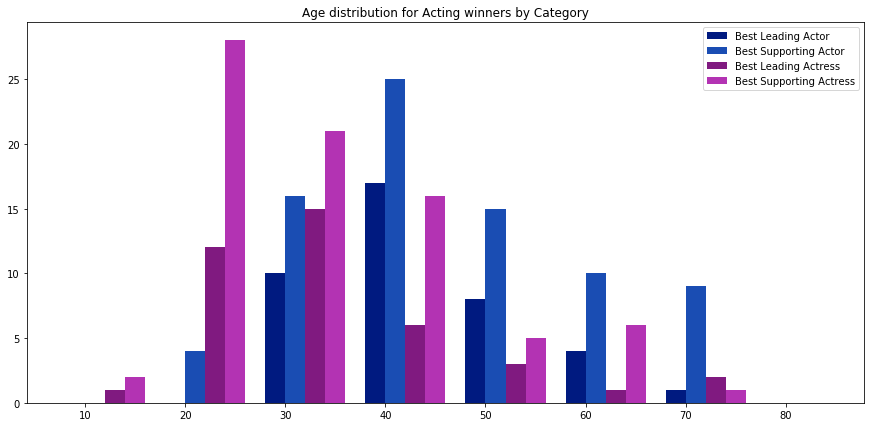

```python
bins = list(range(8, 88, 10))
w = 2
plt.figure(figsize=(15, 7))
plt.hist(df_actors_winners[df_actors_winners['Award'] == 'Actor in a Leading Role']['Age'], bins=bins, width=w, color=[0, 0.1, 0.5], label='Best Leading Actor')
plt.hist(df_actors_winners[df_actors_winners['Award'] == 'Actor in a Supporting Role']['Age'], bins=[x+w for x in bins], width=w, color=[0.1, 0.3, 0.7], label='Best Supporting Actor')
plt.hist(df_actors_winners[df_actors_winners['Award'] == 'Actress in a Leading Role']['Age'], bins=[x+2*w for x in bins], width=w, color=[0.5, 0.1, 0.5], label='Best Leading Actress')
plt.hist(df_actors_winners[df_actors_winners['Award'] == 'Actress in a Supporting Role']['Age'], bins=[x+3*w for x in bins], width=w, color=[0.7, 0.2, 0.7], label='Best Supporting Actress')
plt.legend()
plt.title('Age distribution for Acting winners by Category')
```

Can you see the pink plummeting ? Here are more visual cues :

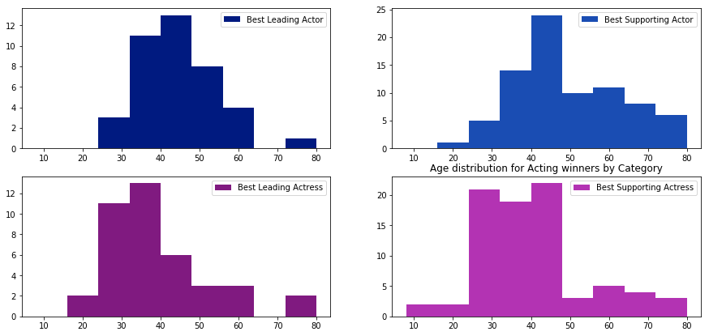

```python
bins = list(range(8, 88, 8))
w = 2
plt.figure(figsize=(15, 7))
plt.subplot(221)
y1 = plt.hist(df_actors_winners[df_actors_winners['Award'] == 'Actor in a Leading Role']['Age'], bins=bins, color=[0, 0.1, 0.5], label='Best Leading Actor')
plt.legend()
plt.subplot(222)
y2 = plt.hist(df_actors_winners[df_actors_winners['Award'] == 'Actor in a Supporting Role']['Age'], bins=bins, color=[0.1, 0.3, 0.7], label='Best Supporting Actor')
plt.legend()
plt.subplot(223)
y3 = plt.hist(df_actors_winners[df_actors_winners['Award'] == 'Actress in a Leading Role']['Age'], bins=bins, color=[0.5, 0.1, 0.5], label='Best Leading Actress')
plt.legend()
plt.subplot(224)
y4 = plt.hist(df_actors_winners[df_actors_winners['Award'] == 'Actress in a Supporting Role']['Age'], bins=bins, color=[0.7, 0.2, 0.7], label='Best Supporting Actress')
plt.legend()
plt.title('Age distribution for Acting winners by Category')
```

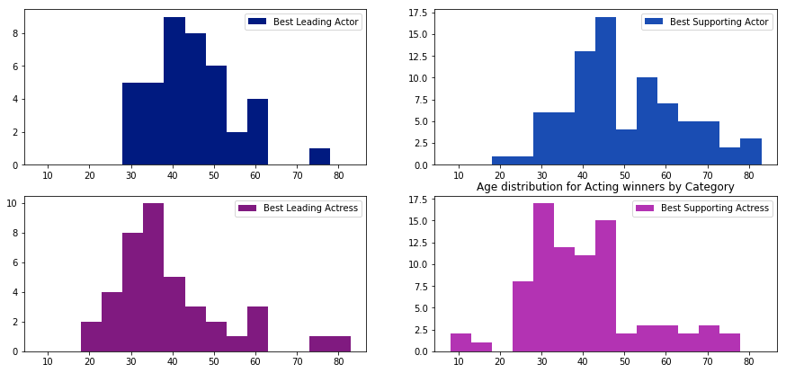

```python
bins = list(range(8, 88, 5))

plt.figure(figsize=(15, 7))
plt.subplot(221)
y1 = plt.hist(df_actors_winners[df_actors_winners['Award'] == 'Actor in a Leading Role']['Age'], bins=bins, color=[0, 0.1, 0.5], label='Best Leading Actor')
plt.legend()
plt.subplot(222)
y2 = plt.hist(df_actors_winners[df_actors_winners['Award'] == 'Actor in a Supporting Role']['Age'], bins=bins, color=[0.1, 0.3, 0.7], label='Best Supporting Actor')
plt.legend()
plt.subplot(223)
y3 = plt.hist(df_actors_winners[df_actors_winners['Award'] == 'Actress in a Leading Role']['Age'], bins=bins, color=[0.5, 0.1, 0.5], label='Best Leading Actress')
plt.legend()
plt.subplot(224)
y4 = plt.hist(df_actors_winners[df_actors_winners['Award'] == 'Actress in a Supporting Role']['Age'], bins=bins, color=[0.7, 0.2, 0.7], label='Best Supporting Actress')
plt.legend()
plt.title('Age distribution for Acting winners by Category')
```

Now this is what sexism looks like, statistically speaking. Men to be generally immune against the effect of aging, being able to score awards years past peak performance (~40), especially in the Supporting category (which is now sometimes ironically called "Lifetime Achievement" category because it's usually given to older actors who've done a lot in their careers but never legitimately won). This generosity, however, doesn't extend to women. As the histogrames show, women have their best shot at winning while they're still "young and attractive", which is consistent with the demography of the 6400 Academy voters (who are revealed publicly so as not to be bribed, but are known to be at least mostly old, mostly white and and mostly men). After the age of 40 (which is about the "shelf life" of most actors, falling out of celebrity and making room to the new generation), women just don't seem to crack the wins.

Except if you're Meryl Streep.

```python
print('Number of wins/nominations by Meryl Streep : 3/' + str(len(df_actors[df_actors['Name'] == 'Meryl Streep'])))
df_actors[df_actors['Name'] == 'Meryl Streep'][['Year_new', 'Award_new', 'Age', 'Film', 'Winner']]
```

```
Number of wins/nominations by Meryl Streep : 3/19
```

|  | Year_new | Award_new | Age | Film | Winner |
| --- | --- | --- | --- | --- | --- |
| 5640 | 1978 | Actress in a Supporting Role | 29 | The Deer Hunter | NaN |
| 5749 | 1979 | Actress in a Supporting Role | 30 | Kramer vs. Kramer | 1.0 |
| 5957 | 1981 | Actress in a Leading Role | 32 | The French Lieutenant's Woman | NaN |
| 6061 | 1982 | Actress in a Leading Role | 33 | Sophie's Choice | 1.0 |
| 6172 | 1983 | Actress in a Leading Role | 34 | Silkwood | NaN |
| 6389 | 1985 | Actress in a Leading Role | 36 | Out of Africa | NaN |
| 6606 | 1987 | Actress in a Leading Role | 38 | Ironweed | NaN |
| 6708 | 1988 | Actress in a Leading Role | 39 | A Cry in the Dark | NaN |
| 6922 | 1990 | Actress in a Leading Role | 41 | Postcards from the Edge | NaN |
| 7483 | 1995 | Actress in a Leading Role | 46 | The Bridges of Madison County | NaN |
| 7835 | 1998 | Actress in a Leading Role | 49 | One True Thing | NaN |
| 7950 | 1999 | Actress in a Leading Role | 50 | Music of the Heart | NaN |
| 8297 | 2002 | Actress in a Supporting Role | 53 | Adaptation | NaN |
| 8748 | 2006 | Actress in a Leading Role | 57 | The Devil Wears Prada | NaN |
| 8983 | 2008 | Actress in a Leading Role | 59 | Doubt | NaN |
| 9098 | 2009 | Actress in a Leading Role | 60 | Julie & Julia | NaN |
| 9347 | 2011 | Actress in a Leading Role | 62 | The Iron Lady | 1.0 |
| 9599 | 2013 | Actress in a Leading Role | 64 | August: Osage County | NaN |
| 9732 | 2014 | Actress in a Supporting Role | 65 | Into the Woods | NaN |

She single-handedly puts 19 nominations in the women categories, the most of any actor ever. Since her first nom in 1978's *The Deer Hunter*, her longest hiatus from the Oscars was a 5 year pause between 1990 to 1995.

As the joke goes : "There *are* great roles for women past the age of 40 in Hollywood! It's just that they all go to Meryl Streep".

### Bonus round

To close this up, let's check on the information we got from DBPedia about the nationality of Oscar nominees/winners.

```python
nationalities = {}
for i, row in df_actors.iterrows():
    for nation in row['nationalities'].split(','):
        if nation in nationalities : nationalities[nation] += 1
        else : nationalities[nation] = 1

print(nationalities)
```

```
{'': 1580, 'United': 29, 'Americans': 9, 'Greeks': 1, 'Welsh': 8, 'Kingdom': 1, 'People': 2, 'Swiss': 3, 'Italian': 2, 'Puerto': 1, 'British': 11, 'Swedish-American': 2, 'French': 2, 'American': 5, 'Great': 1, 'Australian': 7, 'Irish': 2, 'German': 2, ' Irish': 2}
```

Apparently even in the (very few) samples which had their countries annotated, it's suprising to see people coming from all around the world getting nominated and winning. Which is more of a statement about Hollywood than about the Oscars, I guess.

```python
actors_with_height = df_actors[df_actors['height'] > 0]
len(actors_with_height)
```

```
76
```

We only have height info about 76 actors (out of the 906), but it would be a fun note to end on, if we found any correlation between height and winning !

```python
actors_with_height['height'].describe()
```

```
count    76.000000
mean      1.721392
std       0.143847
min       1.170000
25%       1.630750
50%       1.752600
75%       1.828800
max       1.955800
Name: height, dtype: float64
```

```python
actors_with_height[actors_with_height['Winner']== 1]['height'].describe()
```

```
count    13.000000
mean      1.718185
std       0.125345
min       1.524000
25%       1.651000
50%       1.752600
75%       1.828800
max       1.880000
Name: height, dtype: float64
```

Same mean, same spread, even on this small sample.

I got my hopes too high.

# 3. Conclusion, further work and predictions ?

So this was fun ! (Except the data cleaning part which was whatever the opposite of fun is)

A lot of the observed results were mere confirmations of well-known phenomena for the Awards observers (Genre bias, movie length, critical acclaim, actresses ages ..) but others were genuinely surprising (the higher correlation between audience scores and a movie's likelihood to win an oscar, longest losing streaks, movie duration through time ..).

There is a lot that could be studied on Oscarology if more data was available (most notably how the Oscar correlates with other awards that have different/niche voting groups, like Directors Guild Award or the Golden Globes) which can theoretically be collected directly from the IMDB pages of these awards and a some heavy manual formatting. What would be more interesting, though, is to see the impact of winning / getting nominations on the finantial performance of a movie and the career of its cast and crew (how much a typical actor makes vs how much an Oscar-Winning Actor makes, for example).

Another aspect that is really interesting, but pretty impossible to model, is the zeitgeist effect. The Oscars tend to prefer movies that are 'important' over ones that are 'technically better' when the choice has to be made. In times of Wars, movies about heroism and sacrifice were always selected (and since the US is kinda continuously in war somewhere, at least one movie every year should be about war, preferably against Nazi Germany and where the US saves everyone).

2017, for example, already labeled the *Year of the Woman*, has seen in the light of the sexual misconduct allegations coming from all sides, a chance to open the debate about sexism in the movie industry. We showed one aspect of sexism when it comes to awards (women need to be singificantly younger than their male counterpart to win an acting award). That's why it's agreed on, this year, that the winning movie will be lead by a female character, which didn't happen since 2004's *Million Dollar Baby*, 13 YEARS ago). Capturing this kind of context is really hard to do in a model, especially since there can be a lot of relevant themes every year (think racism, immegration and sexual identity as the hot topics of the couple last two years).

On the actors side, a lot can be done as well. The #OscarSoWhite controvery a couple years ago (where all nominees in all acting categories + director were all white) made such waves that the Academy was forced make substantial changes in its voting body, which somehow resulted in last year's Moonlight's surprising win, the first movie ever with an entire black cast to win the big award (not out of charity, since it held a perfect Metascore for a very long time). Analysing race data, especially with regard to the type of roles and characters. This dataset can also be done, but it would require more patience than what I have for the couple weeks to come !

The analysis can and should be extended to the other categories, but that's even harder given how sparse the data was for actors (which are consider celebrities), let alone Special Effect technicians.

In the end, these are just statistics. It would take more than superficial data analysis to understand the behavior of a collective hivemind such as the Academy. That's why, in the end, we just make predictions and hope for the best (/most likely) to win !

## My predictions

(This has nothing to do with the course and I'm just overstaying my welcome)

The award nominations in each category will be announced on the 23rd of January, which will end the speculations on nominations, and give some people the ever-lasting bragging right of being "Oscar nominated". This will also mean the start of the second compaign for award season (when you start seeing and hearing "8 Oscar Nominations" on trailers and posters). And then the bets are made on the winners, which, depending on the years, could be very predictable or very shocking.

So without further ado, here are my nominations (and predicted winners !) for this year's main categories, in decreasing confidence (that I may or may not update after the nominations are annouced) :

### Best Director :

- Guillermo del Toro
- Christopher Nolan
- Greta Gerwig
- Martin McDonagh
- Luca Guadagnino (maybe Steven Spielberg, long shot Jordan Peele)

### Best Animated Movie :

- Coco
- The Breadwinner
- Loving Vincent
- Mary and The Witch Flower
- The Lego Batman movie / The Boss Baby (maybe Ferdinand)

### Best Adapted Screenplay

- Call Me By Your Name
- The Disaster Artist
- Molly's Game
- Mudbound
- Wonder / Wonder Woman

### Best Original Screenplay

- Three Billboards
- Lady Bird
- The Shape of Water
- The Big Sick
- Dunkirk / Get Out / The Post

### Best Supporting Actress

- Laurie Metcalf
- Allison Janney
- Holly Hunter
- Octavia Spencer
- Mary J. Blige / Hong Chau

### Best Supporting Actor

- Sam Rockwell
- Willem Dafoe
- Richard Jenkins
- Armie Hammer
- Woody Harrelson / Michael Stuhlbarg

### Best Leading Actress

- Frances McDormand
- Sally Hawkins
- Saoirse Ronan
- Meryl Streep
- Margot Robbie

### Best Leading Actor

- Gary Oldman
- Timothee Chalamet
- Daniel Day-Lewis
- James Franco
- Daniel Kaluuya / Tom Hanks / Denzel Washington

### Best Picture

- Three Billboards
- The Shape of Water
- Call Me By Your Name
- Lady Bird
- Dunkirk
- Get Out
- The Post
- The Big Sick
- The Florida Project
- Darkest Hours / The Phantom Thread